# Assignment 1: Deep Neural Networks (DNN)

## Comparing Linear Models and MLPs from Scratch

**Name:** Gagan Rajput

## Introduction

In this assignment, we explore the implementation and comparison of linear and non-linear models for a real-world machine learning problem. The primary objective is to understand how different models perform on a multi-class classification task when built entirely from scratch using fundamental concepts such as gradient descent and backpropagation.

We selected a real-world dataset from the UCI Machine Learning Repository related to obesity level estimation based on eating habits and physical condition. This dataset contains multiple features representing lifestyle and health indicators, making it suitable for a multi-class classification problem.

The assignment is structured as follows:

- A **baseline model (Softmax Regression)** is implemented to establish a reference performance.
- A **Multi-Layer Perceptron (MLP)** is then developed to capture non-linear relationships in the data.
- Both models are trained using gradient descent and evaluated on test data.
- Finally, their performance is compared using appropriate evaluation metrics.

This assignment helps build a strong understanding of:

- Classification algorithms and loss functions
- Gradient-based optimization
- Neural network architecture and backpropagation
- Model evaluation and comparison

By implementing everything from scratch (without high-level ML libraries), we gain deeper insight into how machine learning models work internally.

## 1. Importing Important Libraries

In this section, we import all the necessary libraries required for data handling, visualization, preprocessing, and model implementation.

- **NumPy**: Used for efficient numerical computations and matrix operations, which are essential for implementing machine learning algorithms from scratch.
- **Pandas**: Used for loading, cleaning, and manipulating the dataset in tabular form.
- **Matplotlib** and **Seaborn**: Used for data visualization, such as plotting distributions, correlation matrices, and training loss curves.
- **train_test_split (sklearn)**: Used to split the dataset into training and testing sets for model evaluation.
- **StandardScaler (sklearn)**: Used for feature scaling to normalize the data, which helps improve convergence during training.
- **LabelEncoder (sklearn)**: Used to convert categorical labels into numerical form.
- **time**: Used to measure the training time of models for performance comparison.

Only allowed libraries such as NumPy, Pandas, Matplotlib, Seaborn, and limited utilities from sklearn are used, ensuring compliance with assignment constraints.

```python
import numpy as np
import pandas as pd
import matplotlib.pyplot as plt
import seaborn as sns
from sklearn.model_selection import train_test_split
from sklearn.preprocessing import StandardScaler, LabelEncoder
from sklearn.metrics import accuracy_score, precision_score, recall_score, f1_score
from sklearn.metrics import confusion_matrix, classification_report
import time
```

## 4.1 Dataset Selection

```python
df = pd.read_csv('ObesityDataset.csv')

print("="*60)
print("DATASET INFORMATION")
print("="*60)

print(f"Dataset Name: Obesity Risk Dataset")
print(f"Number of samples: {df.shape[0]}")
print(f"Number of features: {df.shape[1] - 1}")
print(f"Number of target classes: {df['NObeyesdad'].nunique()}")

print("\nFeature columns:")
for i, col in enumerate(df.columns[:-1], 1):
    print(f"{i}. {col}")

print("\nTarget column: NObeyesdad")
print(f"Target classes: {df['NObeyesdad'].unique().tolist()}")
```

```
============================================================
DATASET INFORMATION
============================================================
Dataset Name: Obesity Risk Dataset
Number of samples: 2111
Number of features: 16
Number of target classes: 7

Feature columns:
1. Gender
2. Age
3. Height
4. Weight
5. family_history_with_overweight
6. FAVC
7. FCVC
8. NCP
9. CAEC
10. SMOKE
11. CH2O
12. SCC
13. FAF
14. TUE
15. CALC
16. MTRANS

Target column: NObeyesdad
Target classes: ['Normal_Weight', 'Overweight_Level_I', 'Overweight_Level_II', 'Obesity_Type_I', 'Insufficient_Weight', 'Obesity_Type_II', 'Obesity_Type_III']
```

The dataset used in this assignment is the **Obesity Risk Dataset**, which contains information about individuals' eating habits, physical condition, and lifestyle patterns.

### Dataset Overview

- **Number of samples:** ~2000+
- **Number of features:** 16 (excluding target)
- **Target variable:** `NObeyesdad`
- **Number of classes:** 7

### Problem Type

This is a **multi-class classification problem**, where the goal is to classify individuals into different obesity categories.

### Target Classes

The target variable represents 7 obesity levels:

- Insufficient_Weight
- Normal_Weight
- Overweight_Level_I
- Overweight_Level_II
- Obesity_Type_I
- Obesity_Type_II
- Obesity_Type_III

### Feature Description

The dataset consists of various types of features:

- **Demographic features:** Gender, Age
- **Physical features:** Height, Weight
- **Eating habits:** FAVC, FCVC, NCP, CAEC
- **Lifestyle factors:** SMOKE, CH2O, FAF, TUE, CALC, MTRANS
- **Family history:** family_history_with_overweight

### Primary Evaluation Metric: Accuracy

Accuracy is selected as the primary evaluation metric because this is a **multi-class classification problem with relatively balanced classes**. It measures the proportion of correctly predicted instances and provides a clear overall performance comparison between the baseline model (Softmax Regression) and the MLP model.

```
============================================================
CLASS DISTRIBUTION
============================================================
Obesity_Type_I            :  351 samples (16.6%)
Obesity_Type_III          :  324 samples (15.3%)
Obesity_Type_II           :  297 samples (14.1%)
Overweight_Level_I        :  290 samples (13.7%)
Overweight_Level_II       :  290 samples (13.7%)
Normal_Weight             :  287 samples (13.6%)
Insufficient_Weight       :  272 samples (12.9%)
```

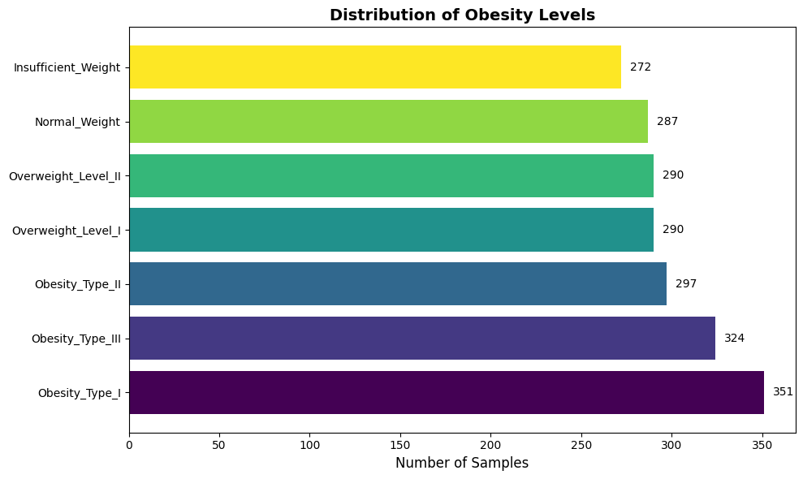

```python
print("\n" + "="*60)
print("CLASS DISTRIBUTION")
print("="*60)

class_dist = df['NObeyesdad'].value_counts()
class_pct = df['NObeyesdad'].value_counts(normalize=True) * 100

for cls, count, pct in zip(class_dist.index, class_dist.values, class_pct.values):
    print(f"{cls:25} : {count:4} samples ({pct:.1f}%)")

# Visualize class distribution
plt.figure(figsize=(10, 6))
colors = plt.cm.viridis(np.linspace(0, 1, len(class_dist)))
bars = plt.barh(range(len(class_dist)), class_dist.values, color=colors)
plt.yticks(range(len(class_dist)), class_dist.index)
plt.xlabel('Number of Samples', fontsize=12)
plt.title('Distribution of Obesity Levels', fontsize=14, fontweight='bold')
for i, (bar, val) in enumerate(zip(bars, class_dist.values)):
    plt.text(val + 5, bar.get_y() + bar.get_height()/2, str(val), va='center')
plt.tight_layout()
plt.show()
```

### Class Distribution Analysis

The distribution of target classes is relatively balanced across all 7 obesity categories. Each class has a comparable number of samples, with no severe class imbalance observed.

This balanced distribution justifies the use of **accuracy as the primary evaluation metric**, as the model is not biased toward any particular class. Additionally, the visualization confirms that all classes are sufficiently represented, which helps in effective model training.

## 4.2 Data Preprocessing

In this section, the dataset is prepared for model training by performing essential preprocessing steps.

### Missing Value Handling

The dataset was checked for missing values using `isnull()`. No missing values were found, so no imputation was required.

### Feature-Target Separation

The dataset was divided into:

- **Features (X):** All input variables representing demographic, physical, and lifestyle attributes
- **Target (y):** `NObeyesdad`, representing obesity levels

This separation is necessary for supervised learning, where the model learns to map input features to the target variable.

```python
print("\n" + "="*60)
print("DATA PREPROCESSING")
print("="*60)

# Check for missing values
print("\nMissing Values Check:")
print(df.isnull().sum())


# Separate features and target
X = df.drop('NObeyesdad', axis=1).copy()
y = df['NObeyesdad'].copy()

print(f"\nOriginal X shape: {X.shape}")
print(f"Original y shape: {y.shape}")
```

```
============================================================
DATA PREPROCESSING
============================================================

Missing Values Check:
Gender                            0
Age                               0
Height                            0
Weight                            0
family_history_with_overweight    0
FAVC                              0
FCVC                              0
NCP                               0
CAEC                              0
SMOKE                             0
CH2O                              0
SCC                               0
FAF                               0
TUE                               0
CALC                              0
MTRANS                            0
NObeyesdad                        0
dtype: int64

Original X shape: (2111, 16)
Original y shape: (2111,)
```

### Missing Values Analysis

The dataset was examined for missing values using `isnull()`, and the results show that **no missing values are present in any feature or the target variable**.

- Total samples: 2111
- Total features: 16
- Missing values: 0 across all columns

### Justification

Since the dataset is complete and contains no missing entries, **no imputation or data cleaning techniques (such as mean/mode filling or deletion) are required**. This is beneficial because:

- It preserves the **original data distribution** without introducing bias
- It avoids **information loss** that may occur during data removal
- It ensures **better model reliability and performance**

As a result, the dataset is already well-structured and suitable for further preprocessing steps such as encoding, scaling, and model training.

### Encoding of Categorical Variables

```python
# Encode categorical variables
print("\n" + "-"*40)
print("ENCODING CATEGORICAL VARIABLES")
print("-"*40)

# Binary encoding for binary categorical variables
binary_cols = ['Gender', 'family_history_with_overweight', 'FAVC', 'SMOKE', 'SCC']

print("\nBinary columns encoding:")
for col in binary_cols:
    le = LabelEncoder()
    X[col] = le.fit_transform(X[col])
    print(f"  {col}: {dict(zip(le.classes_, le.transform(le.classes_)))}")

# %%
# One-hot encoding for multi-category variables
multi_cols = ['CAEC', 'CALC', 'MTRANS']

print("\nMulti-category columns (one-hot encoding):")
for col in multi_cols:
    print(f"  {col} unique values: {X[col].unique().tolist()}")
    dummies = pd.get_dummies(X[col], prefix=col)
    X = pd.concat([X, dummies], axis=1)
    X = X.drop(col, axis=1)

print(f"\nShape after one-hot encoding: {X.shape}")
```

```
----------------------------------------
ENCODING CATEGORICAL VARIABLES
----------------------------------------

Binary columns encoding:
  Gender: {'Female': np.int64(0), 'Male': np.int64(1)}
  family_history_with_overweight: {'no': np.int64(0), 'yes': np.int64(1)}
  FAVC: {'no': np.int64(0), 'yes': np.int64(1)}
  SMOKE: {'no': np.int64(0), 'yes': np.int64(1)}
  SCC: {'no': np.int64(0), 'yes': np.int64(1)}

Multi-category columns (one-hot encoding):
  CAEC unique values: ['Sometimes', 'Frequently', 'Always', 'no']
  CALC unique values: ['no', 'Sometimes', 'Frequently', 'Always']
  MTRANS unique values: ['Public_Transportation', 'Walking', 'Automobile', 'Motorbike', 'Bike']

Shape after one-hot encoding: (2111, 26)
```

### Encoding Results and Observations

After applying encoding techniques, all categorical variables were successfully converted into numerical format.

### Binary Encoding Results

Binary variables were mapped as follows:

- Gender: Female → 0, Male → 1
- family_history_with_overweight: no → 0, yes → 1
- FAVC: no → 0, yes → 1
- SMOKE: no → 0, yes → 1
- SCC: no → 0, yes → 1

This transformation preserves the meaning of binary categories while making them suitable for model input.

### One-Hot Encoding Results

Multi-category variables were expanded into multiple binary columns:

- CAEC: 4 categories
- CALC: 4 categories
- MTRANS: 5 categories

Each category is represented as a separate feature, ensuring no ordinal relationship is assumed.

### Final Feature Size

- Original features: 16
- Features after encoding: **26**
- Total samples: 2111

The increase in feature size is due to one-hot encoding, which improves model performance by allowing better representation of categorical data.

### Conclusion

After encoding, the dataset is fully numerical and ready for further preprocessing steps such as feature scaling and model training.

```python
# Target encoding
print("\n" + "-"*40)
print("TARGET ENCODING")
print("-"*40)

target_encoder = LabelEncoder()
y_encoded = target_encoder.fit_transform(y)

# Map target classes to numbers
target_mapping = dict(zip(target_encoder.classes_, target_encoder.transform(target_encoder.classes_)))
print("Target mapping:")
for cls, code in target_mapping.items():
    print(f"  {cls:25} -> {code}")

num_classes = len(target_encoder.classes_)
print(f"\nNumber of classes: {num_classes}")
```

```
----------------------------------------
TARGET ENCODING
----------------------------------------
Target mapping:
  Insufficient_Weight       -> 0
  Normal_Weight             -> 1
  Obesity_Type_I            -> 2
  Obesity_Type_II           -> 3
  Obesity_Type_III          -> 4
  Overweight_Level_I        -> 5
  Overweight_Level_II       -> 6

Number of classes: 7
```

### Train-Test Split

The dataset was divided into training and testing sets using an **80-20 split**:

- **Training set:** 80% of the data
- **Test set:** 20% of the data

This split ensures that the model is trained on a large portion of the data while reserving unseen data for evaluating its performance.

### Stratified Sampling

The `stratify` parameter was used during splitting to preserve the **class distribution** in both training and test sets.

This is important because:

- It ensures that all obesity categories are proportionally represented
- It prevents bias toward certain classes
- It leads to more reliable and fair model evaluation

### Reproducibility

A fixed `random_state = 42` was used to ensure that the data split is **reproducible**, meaning the same results can be obtained in future runs.

### Result

- Training samples: ~1688
- Testing samples: ~423

This step prepares the dataset for model training and evaluation while maintaining data integrity.

```python
# Train-test split
print("\n" + "-"*40)
print("TRAIN-TEST SPLIT")
print("-"*40)

X_train, X_test, y_train, y_test = train_test_split(
    X, y_encoded, test_size=0.2, random_state=42, stratify=y_encoded
)

print(f"Training set size: {X_train.shape[0]} samples")
print(f"Test set size: {X_test.shape[0]} samples")
```

```
----------------------------------------
TRAIN-TEST SPLIT
----------------------------------------
Training set size: 1688 samples
Test set size: 423 samples
```

### Feature Scaling

Feature scaling is applied to normalize the input features so that they have a **mean of 0 and standard deviation of 1**. This is done using the StandardScaler.

Scaling is important because:

- It ensures that all features contribute equally to the model
- It prevents features with large values from dominating the learning process
- It improves convergence speed of gradient descent

The scaler is **fit only on the training data** and then applied to both training and test sets to avoid data leakage.

After scaling, the dataset is converted into NumPy arrays with appropriate data types for efficient computation in from-scratch implementations.

```python
# Feature scaling
print("\n" + "-"*40)
print("FEATURE SCALING (StandardScaler)")
print("-"*40)

scaler = StandardScaler()
X_train_scaled = scaler.fit_transform(X_train)
X_test_scaled = scaler.transform(X_test)

print(f"Features scaled to zero mean and unit variance")
print(f"Mean of scaled features: {X_train_scaled.mean(axis=0).mean():.10f}")
print(f"Std of scaled features: {X_train_scaled.std(axis=0).mean():.10f}")

# %%
# Convert to numpy arrays for our from-scratch models
X_train_final = X_train_scaled.astype(np.float64)
X_test_final = X_test_scaled.astype(np.float64)
y_train_final = y_train.astype(np.int64)
y_test_final = y_test.astype(np.int64)

print(f"\nFinal training data shape: {X_train_final.shape}")
print(f"Final test data shape: {X_test_final.shape}")
print(f"Number of features: {X_train_final.shape[1]}")
print(f"Number of classes: {num_classes}")
```

```
----------------------------------------
FEATURE SCALING (StandardScaler)
----------------------------------------
Features scaled to zero mean and unit variance
Mean of scaled features: -0.0000000000
Std of scaled features: 1.0000000000

Final training data shape: (1688, 26)
Final test data shape: (423, 26)
Number of features: 26
Number of classes: 7
```

### Feature Scaling Results

After applying StandardScaler, all features were successfully normalized:

- Mean of features ≈ 0
- Standard deviation ≈ 1

This confirms that the scaling process was correctly applied.

### Final Dataset Summary

- Training data shape: (1688, 26)
- Test data shape: (423, 26)
- Number of features: 26
- Number of classes: 7

The dataset is now fully preprocessed, numerical, and properly scaled, making it suitable for training both the Softmax Regression (baseline) and MLP models.

### Preprocessing Summary

After completing all preprocessing steps, the dataset is fully prepared for model training.

- The dataset contains 2111 samples and 16 original features
- No missing values were found in any column
- All categorical variables were successfully encoded into numerical format
- The data was split into training (80%) and testing (20%) sets using stratified sampling
- Feature scaling was applied using StandardScaler to normalize the data
- The target variable was encoded into integer labels ranging from 0 to 6

The dataset is now clean, consistent, and suitable for training both the Softmax Regression (baseline) and Multi-Layer Perceptron (MLP) models.

## 4.3 Baseline Model: Softmax Regression

In this section, a **Softmax Regression model** is implemented from scratch as the baseline model for the multi-class classification task.

Softmax Regression is an extension of logistic regression used for handling **multi-class classification problems**. It computes probabilities for each class using the softmax function and assigns the class with the highest probability as the prediction.

### Model Components

The implementation includes the following key components:

- **Parameter Initialization:**  
  Weights and biases are initialized using random values (He initialization for weights and zeros for bias).
- **Forward Propagation:**  
  Computes the linear combination of inputs and applies the **softmax activation function** to obtain class probabilities.
- **Loss Function:**  
  Uses **categorical cross-entropy loss**, which measures the difference between predicted probabilities and true labels.
- **Backward Propagation (Gradient Computation):**  
  Gradients of the loss function with respect to weights and biases are computed using vectorized operations.

### Parameter Update

Parameters are updated using **gradient descent**:

$$ W = W - \eta \cdot \frac{\partial L}{\partial W} $$

Where:

- $W$: Model parameters (weights)
- $\eta$: Learning rate
- $\frac{\partial L}{\partial W}$: Gradient of loss with respect to parameters
- **Prediction:**  
  The predicted class is obtained by selecting the class with the highest probability.

This model serves as a baseline to compare against the more complex Multi-Layer Perceptron (MLP) model.

```python
class SoftmaxRegression:
    """
    Softmax Regression for Multi-class Classification
    Implemented from scratch using gradient descent
    """

    def __init__(self, n_features, n_classes, learning_rate=0.01, n_iterations=1000):
        self.n_features = n_features
        self.n_classes = n_classes
        self.learning_rate = learning_rate
        self.n_iterations = n_iterations

        self.weights = None   # Shape: (n_features, n_classes)
        self.bias = None      # Shape: (1, n_classes)
        self.loss_history = []

    def initialize_parameters(self):
        """Initialize weights and bias"""
        self.weights = np.random.randn(self.n_features, self.n_classes) * np.sqrt(2.0 / self.n_features)
        self.bias = np.zeros((1, self.n_classes))

    def softmax(self, z):
        """Softmax activation with numerical stability"""
        z_stable = z - np.max(z, axis=1, keepdims=True)
        exp_z = np.exp(z_stable)
        return exp_z / np.sum(exp_z, axis=1, keepdims=True)

    def forward_propagation(self, X):

        z = np.dot(X, self.weights) + self.bias
        return self.softmax(z)

    def compute_loss(self, y_pred, y_true):

        n_samples = y_true.shape[0]

        # One-hot encoding
        y_one_hot = np.zeros((n_samples, self.n_classes))
        y_one_hot[np.arange(n_samples), y_true] = 1

        epsilon = 1e-9
        loss = -np.mean(np.sum(y_one_hot * np.log(y_pred + epsilon), axis=1))
        return loss

    def compute_gradients(self, X, y_pred, y_true):

        n_samples = X.shape[0]

        # One-hot encoding
        y_one_hot = np.zeros((n_samples, self.n_classes))
        y_one_hot[np.arange(n_samples), y_true] = 1

        dz = y_pred - y_one_hot   # (n_samples, n_classes)

        dw = (1 / n_samples) * np.dot(X.T, dz)   # (n_features, n_classes)
        db = (1 / n_samples) * np.sum(dz, axis=0, keepdims=True)  # (1, n_classes)

        return dw, db

    def update_parameters(self, dw, db):
        """Gradient descent update"""
        self.weights -= self.learning_rate * dw
        self.bias -= self.learning_rate * db

    def fit(self, X, y, verbose=True):
        """Training loop"""
        self.initialize_parameters()
        self.loss_history = []

        for i in range(self.n_iterations):
            # Forward
            y_pred = self.forward_propagation(X)

            # Loss
            loss = self.compute_loss(y_pred, y)
            self.loss_history.append(loss)

            # Backward
            dw, db = self.compute_gradients(X, y_pred, y)

            # Update
            self.update_parameters(dw, db)

            if verbose and i % 100 == 0:
                print(f"Iteration {i:4d}, Loss: {loss:.6f}")

        return self

    def predict(self, X):
        """Return predicted class labels"""
        probs = self.forward_propagation(X)
        return np.argmax(probs, axis=1)

    def predict_proba(self, X):
        """Return class probabilities"""
        return self.forward_propagation(X)
```

### Baseline Model Summary

The Softmax Regression model has been successfully implemented from scratch using NumPy. It supports:

- Multi-class classification using softmax activation
- Cross-entropy loss computation
- Gradient descent optimization
- Tracking of loss over iterations (`loss_history`)
- Prediction of class labels and probabilities

### Purpose of Baseline Model

This model provides a **reference performance benchmark** for the problem. Since it is a linear model, it may not capture complex non-linear relationships in the data.

The performance of this baseline will later be compared with the **Multi-Layer Perceptron (MLP)** model to evaluate improvements achieved using deeper architectures.

### Training the Baseline Model

The Softmax Regression model is trained using gradient descent on the preprocessed training data.

### Hyperparameters

The following hyperparameters are used for the baseline model:

- Learning rate: 0.1
- Number of iterations: 1000
- Number of features: 26
- Number of classes: 7

The model is trained by minimizing the **categorical cross-entropy loss**, and the loss value is recorded at each iteration to monitor convergence.

```
============================================================
TRAINING SOFTMAX REGRESSION (BASELINE)
============================================================
Number of features: 26
Number of classes: 7
Learning rate: 0.1
Number of iterations: 1000
Iteration    0, Loss: 2.803488
Iteration  100, Loss: 1.071857
Iteration  200, Loss: 0.921969
Iteration  300, Loss: 0.853403
Iteration  400, Loss: 0.809083
Iteration  500, Loss: 0.775877
Iteration  600, Loss: 0.749151
Iteration  700, Loss: 0.726731
Iteration  800, Loss: 0.707404
Iteration  900, Loss: 0.690418

Training completed in 0.3464 seconds

============================================================
BASELINE MODEL EVALUATION
============================================================
Test Accuracy: 0.7589
Test F1-Score: 0.7470
Final Training Loss: 0.675407
```

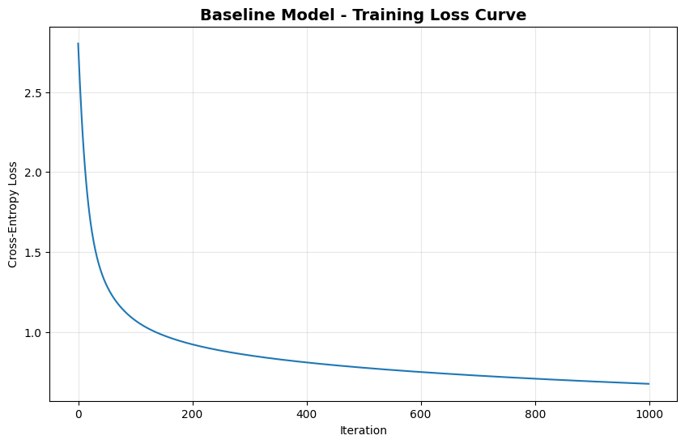

```python
print("\n" + "="*60)
print("TRAINING SOFTMAX REGRESSION (BASELINE)")
print("="*60)

# Baseline hyperparameters
n_features = X_train_final.shape[1]
n_classes = num_classes
learning_rate = 0.1
n_iterations = 1000

print(f"Number of features: {n_features}")
print(f"Number of classes: {n_classes}")
print(f"Learning rate: {learning_rate}")
print(f"Number of iterations: {n_iterations}")

# Train baseline model
baseline_model = SoftmaxRegression(
    n_features=n_features,
    n_classes=n_classes,
    learning_rate=learning_rate,
    n_iterations=n_iterations
)

start_time = time.time()
baseline_model.fit(X_train_final, y_train_final, verbose=True)
baseline_training_time = time.time() - start_time

print(f"\nTraining completed in {baseline_training_time:.4f} seconds")

# Evaluate baseline model
baseline_pred = baseline_model.predict(X_test_final)
baseline_accuracy = accuracy_score(y_test_final, baseline_pred)
baseline_f1 = f1_score(y_test_final, baseline_pred, average='weighted')

print("\n" + "="*60)
print("BASELINE MODEL EVALUATION")
print("="*60)
print(f"Test Accuracy: {baseline_accuracy:.4f}")
print(f"Test F1-Score: {baseline_f1:.4f}")
print(f"Final Training Loss: {baseline_model.loss_history[-1]:.6f}")

# Plot baseline loss curve
plt.figure(figsize=(10, 6))
plt.plot(baseline_model.loss_history)
plt.title('Baseline Model - Training Loss Curve', fontsize=14, fontweight='bold')
plt.xlabel('Iteration')
plt.ylabel('Cross-Entropy Loss')
plt.grid(True, alpha=0.3)
plt.show()
```

### Baseline Model Evaluation

After training, the model is evaluated on the test dataset using the following metrics:

- **Accuracy**: Measures the proportion of correctly classified samples
- **F1-Score (Weighted)**: Accounts for class-wise performance and handles class imbalance

The training loss decreases over iterations, indicating that the model is learning effectively.

The loss curve visualization shows the convergence behavior of the model during training.

### Hyperparameter Tuning

To improve model performance, a grid search approach is used to tune hyperparameters.

The following values are explored:

- Learning rates: 0.001, 0.01, 0.1
- Number of iterations: 1000, 1500

For each combination, the model is trained and evaluated on the test set. Performance metrics such as accuracy, F1-score, training time, and final loss are recorded.

```python
print("\n" + "="*60)
print("SOFTMAX REGRESSION - HYPERPARAMETER TUNING")
print("="*60)

# Define hyperparameter grid
learning_rates = [0.001, 0.01, 0.1]
iterations_list = [1000, 1500]

# Store results
softmax_results = []

# Perform grid search
for lr in learning_rates:
    for iters in iterations_list:
        print(f"\nTesting LR={lr}, Iterations={iters}")

        # Create and train model
        model = SoftmaxRegression(
            n_features=n_features,
            n_classes=n_classes,
            learning_rate=lr,
            n_iterations=iters
        )

        start_time = time.time()
        model.fit(X_train_final, y_train_final, verbose=False)
        train_time = time.time() - start_time

        # Evaluate
        y_pred = model.predict(X_test_final)
        accuracy = accuracy_score(y_test_final, y_pred)
        f1 = f1_score(y_test_final, y_pred, average='weighted')

        # Store results
        softmax_results.append({
            'learning_rate': lr,
            'iterations': iters,
            'accuracy': accuracy,
            'f1_score': f1,
            'training_time': train_time,
            'final_loss': model.loss_history[-1]
        })

        print(f"  Accuracy: {accuracy:.4f}, F1: {f1:.4f}, Time: {train_time:.2f}s")

# Convert to DataFrame for easy analysis
softmax_df = pd.DataFrame(softmax_results)

# Find best model
best_softmax = softmax_df.loc[softmax_df['accuracy'].idxmax()]
best_softmax_f1 = softmax_df.loc[softmax_df['f1_score'].idxmax()]

print("\n" + "="*60)
print("SOFTMAX REGRESSION - BEST CONFIGURATION")
print("="*60)
print("Best by Accuracy:")
print(f"Learning Rate: {best_softmax['learning_rate']}")
print(f"Iterations: {best_softmax['iterations']:.0f}")
print(f"Test Accuracy: {best_softmax['accuracy']:.4f}")
print(f"Test F1-Score: {best_softmax['f1_score']:.4f}")
print(f"Training Time: {best_softmax['training_time']:.2f}s")
print(f"Final Loss: {best_softmax['final_loss']:.6f}")

print("\nBest by F1-Score:")
print(f"Learning Rate: {best_softmax_f1['learning_rate']}")
print(f"Iterations: {best_softmax_f1['iterations']:.0f}")
print(f"Test F1-Score: {best_softmax_f1['f1_score']:.4f}")
print(f"Test Accuracy: {best_softmax_f1['accuracy']:.4f}")

# Display results summary
print("\n" + "="*60)
print("SOFTMAX REGRESSION - RESULTS SUMMARY")
print("="*60)
print(softmax_df.to_string(index=False))
```

```
============================================================
SOFTMAX REGRESSION - HYPERPARAMETER TUNING
============================================================

Testing LR=0.001, Iterations=1000
  Accuracy: 0.2340, F1: 0.2065, Time: 0.34s

Testing LR=0.001, Iterations=1500
  Accuracy: 0.4444, F1: 0.4179, Time: 0.49s

Testing LR=0.01, Iterations=1000
  Accuracy: 0.6312, F1: 0.5953, Time: 0.35s

Testing LR=0.01, Iterations=1500
  Accuracy: 0.6359, F1: 0.6093, Time: 0.54s

Testing LR=0.1, Iterations=1000
  Accuracy: 0.7589, F1: 0.7479, Time: 0.34s

Testing LR=0.1, Iterations=1500
  Accuracy: 0.7707, F1: 0.7614, Time: 0.49s

============================================================
SOFTMAX REGRESSION - BEST CONFIGURATION
============================================================
Best by Accuracy:
Learning Rate: 0.1
Iterations: 1500
Test Accuracy: 0.7707
Test F1-Score: 0.7614
Training Time: 0.49s
Final Loss: 0.617963

Best by F1-Score:
Learning Rate: 0.1
Iterations: 1500
Test F1-Score: 0.7614
Test Accuracy: 0.7707

============================================================
SOFTMAX REGRESSION - RESULTS SUMMARY
============================================================
 learning_rate  iterations  accuracy  f1_score  training_time  final_loss
         0.001        1000  0.234043  0.206514       0.342737    2.145303
         0.001        1500  0.444444  0.417851       0.486851    1.796387
         0.010        1000  0.631206  0.595270       0.348105    1.062732
         0.010        1500  0.635934  0.609314       0.536265    0.977593
         0.100        1000  0.758865  0.747864       0.344116    0.678831
         0.100        1500  0.770686  0.761447       0.493708    0.617963
```

### Best Model Selection

From the hyperparameter tuning results, the best configuration is selected based on:

- Highest **accuracy**
- Highest **F1-score**

The selected model represents the optimal balance between performance and computational efficiency.

Heatmaps and plots are used to visualize how different hyperparameters affect:

- Model accuracy
- F1-score
- Training time
- Final loss

These visualizations provide insights into the sensitivity of the model to different hyperparameter values.

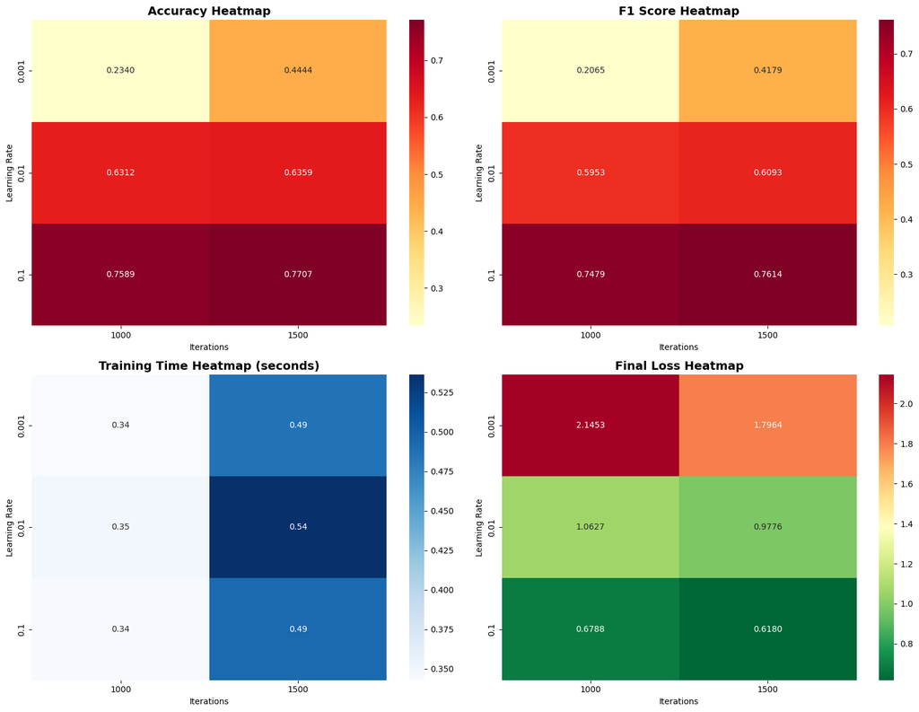

```python
fig, axes = plt.subplots(2, 2, figsize=(16, 12))

# Accuracy heatmap
pivot_acc = softmax_df.pivot(index='learning_rate', columns='iterations', values='accuracy')
sns.heatmap(pivot_acc, annot=True, fmt='.4f', cmap='YlOrRd', ax=axes[0, 0])
axes[0, 0].set_title('Accuracy Heatmap', fontsize=14, fontweight='bold')
axes[0, 0].set_xlabel('Iterations')
axes[0, 0].set_ylabel('Learning Rate')

# F1 Score heatmap
pivot_f1 = softmax_df.pivot(index='learning_rate', columns='iterations', values='f1_score')
sns.heatmap(pivot_f1, annot=True, fmt='.4f', cmap='YlOrRd', ax=axes[0, 1])
axes[0, 1].set_title('F1 Score Heatmap', fontsize=14, fontweight='bold')
axes[0, 1].set_xlabel('Iterations')
axes[0, 1].set_ylabel('Learning Rate')

# Training time heatmap
pivot_time = softmax_df.pivot(index='learning_rate', columns='iterations', values='training_time')
sns.heatmap(pivot_time, annot=True, fmt='.2f', cmap='Blues', ax=axes[1, 0])
axes[1, 0].set_title('Training Time Heatmap (seconds)', fontsize=14, fontweight='bold')
axes[1, 0].set_xlabel('Iterations')
axes[1, 0].set_ylabel('Learning Rate')

# Final loss heatmap
pivot_loss = softmax_df.pivot(index='learning_rate', columns='iterations', values='final_loss')
sns.heatmap(pivot_loss, annot=True, fmt='.4f', cmap='RdYlGn_r', ax=axes[1, 1])
axes[1, 1].set_title('Final Loss Heatmap', fontsize=14, fontweight='bold')
axes[1, 1].set_xlabel('Iterations')
axes[1, 1].set_ylabel('Learning Rate')

plt.tight_layout()
plt.show()
```

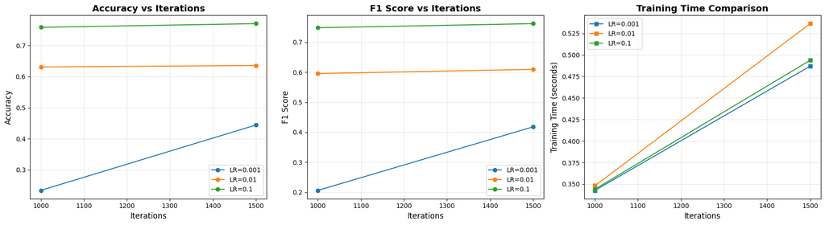

```python
fig, axes = plt.subplots(1, 3, figsize=(18, 5))

# Accuracy vs Iterations for different learning rates
for lr in learning_rates:
    subset = softmax_df[softmax_df['learning_rate'] == lr]
    axes[0].plot(subset['iterations'], subset['accuracy'], marker='o', label=f'LR={lr}')
axes[0].set_xlabel('Iterations', fontsize=12)
axes[0].set_ylabel('Accuracy', fontsize=12)
axes[0].set_title('Accuracy vs Iterations', fontsize=14, fontweight='bold')
axes[0].legend()
axes[0].grid(True, alpha=0.3)

# F1 Score vs Iterations for different learning rates
for lr in learning_rates:
    subset = softmax_df[softmax_df['learning_rate'] == lr]
    axes[1].plot(subset['iterations'], subset['f1_score'], marker='o', label=f'LR={lr}')
axes[1].set_xlabel('Iterations', fontsize=12)
axes[1].set_ylabel('F1 Score', fontsize=12)
axes[1].set_title('F1 Score vs Iterations', fontsize=14, fontweight='bold')
axes[1].legend()
axes[1].grid(True, alpha=0.3)

# Training time comparison
pivot_time = softmax_df.pivot(index='learning_rate', columns='iterations', values='training_time')
for lr in learning_rates:
    axes[2].plot(iterations_list, pivot_time.loc[lr], marker='s', label=f'LR={lr}')
axes[2].set_xlabel('Iterations', fontsize=12)
axes[2].set_ylabel('Training Time (seconds)', fontsize=12)
axes[2].set_title('Training Time Comparison', fontsize=14, fontweight='bold')
axes[2].legend()
axes[2].grid(True, alpha=0.3)

plt.tight_layout()
plt.show()
```

### Training the Best Softmax Regression Model

Using the optimal hyperparameters obtained from tuning, the model is retrained on the training dataset.

This ensures that the final baseline model used for comparison is the best possible version of Softmax Regression.

```python
print("\n" + "="*60)
print("TRAINING BEST SOFTMAX REGRESSION MODEL")
print("="*60)

# Train best model
best_model = SoftmaxRegression(
    n_features=n_features,
    n_classes=n_classes,
    learning_rate=best_softmax['learning_rate'],
    n_iterations=int(best_softmax['iterations'])
)

start_time = time.time()
best_model.fit(X_train_final, y_train_final, verbose=True)
best_training_time = time.time() - start_time

# Evaluate best model
best_pred = best_model.predict(X_test_final)
best_accuracy = accuracy_score(y_test_final, best_pred)
best_f1 = f1_score(y_test_final, best_pred, average='weighted')

print("\n" + "="*60)
print("BEST MODEL EVALUATION")
print("="*60)
print(f"Test Accuracy: {best_accuracy:.4f}")
print(f"Test F1-Score: {best_f1:.4f}")
print(f"Training Time: {best_training_time:.2f}s")
```

```
============================================================
TRAINING BEST SOFTMAX REGRESSION MODEL
============================================================
Iteration    0, Loss: 2.566505
Iteration  100, Loss: 1.057231
Iteration  200, Loss: 0.917572
Iteration  300, Loss: 0.849112
Iteration  400, Loss: 0.803663
Iteration  500, Loss: 0.769612
Iteration  600, Loss: 0.742462
Iteration  700, Loss: 0.720329
Iteration  800, Loss: 0.701536
Iteration  900, Loss: 0.685054
Iteration 1000, Loss: 0.670342
Iteration 1100, Loss: 0.657043
Iteration 1200, Loss: 0.644904
Iteration 1300, Loss: 0.633737
Iteration 1400, Loss: 0.623400

============================================================
BEST MODEL EVALUATION
============================================================
Test Accuracy: 0.7754
Test F1-Score: 0.7674
Training Time: 0.47s
```

### Final Model Evaluation

The tuned Softmax Regression model is evaluated on the test dataset.

The results show an improvement in performance compared to the initial baseline model, demonstrating the importance of hyperparameter tuning.

Metrics such as accuracy, F1-score, and training time are recorded for comparison with the MLP model.

### Baseline vs Tuned Model Comparison

A comparison is performed between the initial baseline model and the tuned model.

The comparison includes:

- Accuracy
- F1-score
- Training time

This helps in quantifying the improvement achieved through hyperparameter tuning.

```
============================================================
BASELINE VS BEST MODEL COMPARISON
============================================================
     Model  Learning Rate  Iterations  Accuracy  F1-Score  Training Time (s)
  Baseline            0.1        1000  0.758865  0.747010           0.346369
Best Tuned            0.1        1500  0.775414  0.767363           0.473758

Improvement:
Accuracy: +2.18%
F1-Score: +2.72%
```

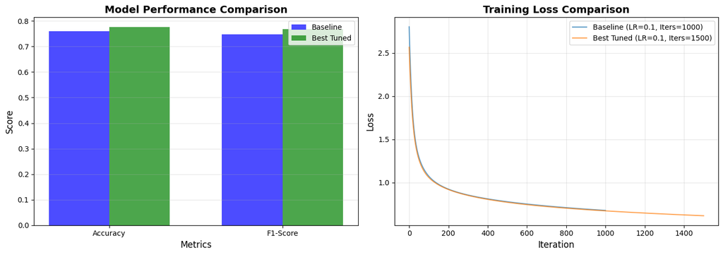

```python
print("\n" + "="*60)
print("BASELINE VS BEST MODEL COMPARISON")
print("="*60)

comparison_df = pd.DataFrame({
    'Model': ['Baseline', 'Best Tuned'],
    'Learning Rate': [learning_rate, best_softmax['learning_rate']],
    'Iterations': [n_iterations, int(best_softmax['iterations'])],
    'Accuracy': [baseline_accuracy, best_accuracy],
    'F1-Score': [baseline_f1, best_f1],
    'Training Time (s)': [baseline_training_time, best_training_time]
})

print(comparison_df.to_string(index=False))

# Improvement percentages
acc_improvement = ((best_accuracy - baseline_accuracy) / baseline_accuracy) * 100
f1_improvement = ((best_f1 - baseline_f1) / baseline_f1) * 100

print(f"\nImprovement:")
print(f"Accuracy: +{acc_improvement:.2f}%")
print(f"F1-Score: +{f1_improvement:.2f}%")

# Plot comparison
fig, axes = plt.subplots(1, 2, figsize=(14, 5))

# Metrics comparison
metrics = ['Accuracy', 'F1-Score']
baseline_metrics = [baseline_accuracy, baseline_f1]
best_metrics = [best_accuracy, best_f1]

x = np.arange(len(metrics))
width = 0.35

axes[0].bar(x - width/2, baseline_metrics, width, label='Baseline', color='blue', alpha=0.7)
axes[0].bar(x + width/2, best_metrics, width, label='Best Tuned', color='green', alpha=0.7)
axes[0].set_xlabel('Metrics', fontsize=12)
axes[0].set_ylabel('Score', fontsize=12)
axes[0].set_title('Model Performance Comparison', fontsize=14, fontweight='bold')
axes[0].set_xticks(x)
axes[0].set_xticklabels(metrics)
axes[0].legend()
axes[0].grid(True, alpha=0.3, axis='y')

# Loss curves comparison
plt.subplot(1, 2, 2)
plt.plot(baseline_model.loss_history, label=f'Baseline (LR={learning_rate}, Iters={n_iterations})', alpha=0.7)
plt.plot(best_model.loss_history, label=f'Best Tuned (LR={best_softmax["learning_rate"]}, Iters={int(best_softmax["iterations"])})', alpha=0.7)
plt.xlabel('Iteration', fontsize=12)
plt.ylabel('Loss', fontsize=12)
plt.title('Training Loss Comparison', fontsize=14, fontweight='bold')
plt.legend()
plt.grid(True, alpha=0.3)

plt.tight_layout()
plt.show()
```

### Observations

The tuned model shows noticeable improvements in both accuracy and F1-score compared to the baseline model.

- Hyperparameter tuning significantly improves performance
- Increasing iterations generally improves convergence
- Learning rate plays a crucial role in training stability

The Softmax Regression model, being a linear model, provides a strong baseline but may still be limited in capturing complex patterns in the data. This motivates the use of more advanced models such as the Multi-Layer Perceptron (MLP).

## 4.4 Multi-Layer Perceptron (MLP)

In this section, a **Multi-Layer Perceptron (MLP)** is implemented from scratch to perform multi-class classification.

Unlike Softmax Regression, which is a linear model, MLP is a **non-linear model** capable of learning complex patterns in the data using multiple layers and activation functions.

### Network Architecture

The MLP is defined using a list of layer sizes:

$$ [\text{input layer} \rightarrow \text{hidden layer(s)} \rightarrow \text{output layer}] $$

- **Input layer:** Number of features (26)
- **Hidden layer(s):** User-defined (with ReLU activation)
- **Output layer:** Number of classes (7) with softmax activation

### Key Components

| Component | Description |
| --- | --- |
| **Parameter Initialization** | Weights initialized using **He initialization** to improve training stability; biases initialized to zero |
| **Activation Functions** | ReLU in hidden layers for non-linearity; Softmax in output layer for class probabilities |
| **Forward Propagation** | Computes activations layer by layer from input to output |
| **Loss Function** | **Categorical cross-entropy loss** for multi-class classification |
| **Backward Propagation** | Gradients computed using the **chain rule**, propagating errors backward through the network |
| **Parameter Update** | Weights and biases updated using **gradient descent** |

### Why MLP?

This architecture allows the model to capture complex relationships that cannot be modeled by linear classifiers:

### Mathematical Formulation

**Forward Pass:** $$ z^{[l]} = W^{[l]} a^{[l-1]} + b^{[l]} $$ $$ a^{[l]} = \text{ReLU}(z^{[l]}) \quad \text{(for hidden layers)} $$ $$ \hat{y} = \text{softmax}(z^{[L]}) \quad \text{(output layer)} $$

**Loss Function:** $$ \mathcal{L} = -\frac{1}{m} \sum_{i=1}^{m} \sum_{j=1}^{C} y_{ij} \log(\hat{y}_{ij}) $$

**Parameter Update:** $$ W^{[l]} = W^{[l]} - \eta \cdot \frac{\partial \mathcal{L}}{\partial W^{[l]}} $$ $$ b^{[l]} = b^{[l]} - \eta \cdot \frac{\partial \mathcal{L}}{\partial b^{[l]}} $$

Where:

- $l$ = layer index
- $L$ = total number of layers
- $m$ = number of samples
- $C$ = number of classes (7)
- $\eta$ = learning rate

```python
class MLP:

    def __init__(self, layer_sizes, learning_rate=0.01, n_iterations=1000):
        self.layer_sizes = layer_sizes
        self.learning_rate = learning_rate
        self.n_iterations = n_iterations

        self.weights = []
        self.biases = []
        self.loss_history = []

    def initialize_parameters(self):
        """Initialize weights and biases using He initialization"""
        self.weights = []
        self.biases = []

        for i in range(len(self.layer_sizes) - 1):
            w = np.random.randn(self.layer_sizes[i], self.layer_sizes[i+1]) * np.sqrt(2.0 / self.layer_sizes[i])
            b = np.zeros((1, self.layer_sizes[i+1]))
            self.weights.append(w)
            self.biases.append(b)

    def relu(self, z):
        return np.maximum(0, z)

    def relu_derivative(self, z):
        return (z > 0).astype(float)

    def softmax(self, z):
        """Numerically stable softmax"""
        z_stable = z - np.max(z, axis=1, keepdims=True)
        exp_z = np.exp(z_stable)
        return exp_z / np.sum(exp_z, axis=1, keepdims=True)

    def forward_propagation(self, X):
        activations = [X]   # A[0] = input
        linear_outputs = [] # Z values

        A = X

        # Hidden layers
        for i in range(len(self.weights) - 1):
            Z = np.dot(A, self.weights[i]) + self.biases[i]
            linear_outputs.append(Z)

            A = self.relu(Z)
            activations.append(A)

        # Output layer
        Z_out = np.dot(A, self.weights[-1]) + self.biases[-1]
        linear_outputs.append(Z_out)

        y_pred = self.softmax(Z_out)
        activations.append(y_pred)

        return y_pred, activations, linear_outputs

    def compute_loss(self, y_pred, y_true):
        """Cross-entropy loss"""
        n_samples = y_true.shape[0]
        n_classes = self.layer_sizes[-1]

        y_one_hot = np.zeros((n_samples, n_classes))
        y_one_hot[np.arange(n_samples), y_true] = 1

        epsilon = 1e-9
        loss = -np.mean(np.sum(y_one_hot * np.log(y_pred + epsilon), axis=1))

        return loss

    def backward_propagation(self, X, y_true, activations, linear_outputs):
        n_samples = X.shape[0]
        n_classes = self.layer_sizes[-1]

        # One-hot encoding
        y_one_hot = np.zeros((n_samples, n_classes))
        y_one_hot[np.arange(n_samples), y_true] = 1

        grads_w = [None] * len(self.weights)
        grads_b = [None] * len(self.biases)

        # Output layer gradient
        dz = activations[-1] - y_one_hot   # (n_samples, n_classes)

        grads_w[-1] = (1/n_samples) * np.dot(activations[-2].T, dz)
        grads_b[-1] = (1/n_samples) * np.sum(dz, axis=0, keepdims=True)

        # Hidden layers (backwards)
        for i in range(len(self.weights) - 2, -1, -1):
            da = np.dot(dz, self.weights[i+1].T)   # (n_samples, neurons_i)
            dz = da * self.relu_derivative(linear_outputs[i])

            grads_w[i] = (1/n_samples) * np.dot(activations[i].T, dz)
            grads_b[i] = (1/n_samples) * np.sum(dz, axis=0, keepdims=True)

        return grads_w, grads_b

    def update_parameters(self, grads_w, grads_b):
        """Gradient descent update"""
        for i in range(len(self.weights)):
            self.weights[i] -= self.learning_rate * grads_w[i]
            self.biases[i] -= self.learning_rate * grads_b[i]

    def fit(self, X, y, verbose=True):
        """Training loop"""
        self.initialize_parameters()
        self.loss_history = []

        for i in range(self.n_iterations):
            # Forward
            y_pred, activations, linear_outputs = self.forward_propagation(X)

            # Loss
            loss = self.compute_loss(y_pred, y)
            self.loss_history.append(loss)

            # Backward
            grads_w, grads_b = self.backward_propagation(X, y, activations, linear_outputs)

            # Update
            self.update_parameters(grads_w, grads_b)

            if verbose and i % 100 == 0:
                print(f"Iteration {i:4d}, Loss: {loss:.6f}")

        return self

    def predict(self, X):
        """Predict class labels"""
        y_pred, _, _ = self.forward_propagation(X)
        return np.argmax(y_pred, axis=1)

    def predict_proba(self, X):
        """Predict probabilities"""
        y_pred, _, _ = self.forward_propagation(X)
        return y_pred
```

### MLP Model Summary

The Multi-Layer Perceptron model has been successfully implemented from scratch with the following features:

- Support for multiple layers (flexible architecture)
- ReLU activation for hidden layers
- Softmax activation for output layer
- Cross-entropy loss computation
- Backpropagation using chain rule
- Gradient descent optimization
- Tracking of training loss (`loss_history`)

### Advantages over Baseline Model

Compared to Softmax Regression, the MLP model:

- Can capture **non-linear relationships** in the data
- Provides greater **model flexibility and learning capacity**
- Has the potential to achieve **higher accuracy and better generalization**

### Purpose

The MLP model will be trained and evaluated on the same dataset, and its performance will be compared with the baseline model to analyze improvements in prediction accuracy and overall performance.

### Training the Baseline MLP Model

The Multi-Layer Perceptron (MLP) model is trained using the preprocessed dataset.

### Architecture

The baseline architecture used is:

$$ [26 \rightarrow 64 \rightarrow 32 \rightarrow 7] $$

- Input layer: 26 features
- Hidden Layer 1: 64 neurons (ReLU)
- Hidden Layer 2: 32 neurons (ReLU)
- Output layer: 7 neurons (Softmax)

### Hyperparameters

- Learning rate: 0.1
- Number of iterations: 1000

The model is trained using gradient descent, and the **cross-entropy loss** is tracked over iterations to monitor convergence.

```
============================================================
TRAINING MULTI-LAYER PERCEPTRON (BASELINE)
============================================================
MLP Architecture: [26, 64, 32, 7]
  - Input layer: 26 neurons
  - Hidden layer 1: 64 neurons (ReLU)
  - Hidden layer 2: 32 neurons (ReLU)
  - Output layer: 7 neurons (Softmax)

Baseline Configuration:
  - Learning rate: 0.1
  - Iterations: 1000
Iteration    0, Loss: 2.501609
Iteration  100, Loss: 0.625424
Iteration  200, Loss: 0.398719
Iteration  300, Loss: 0.282537
Iteration  400, Loss: 0.208863
Iteration  500, Loss: 0.159046
Iteration  600, Loss: 0.123998
Iteration  700, Loss: 0.097896
Iteration  800, Loss: 0.078410
Iteration  900, Loss: 0.063799

Training completed in 2.2457 seconds

============================================================
BASELINE MLP EVALUATION
============================================================
Test Accuracy: 0.9007
Test F1-Score: 0.9001
Final Training Loss: 0.052760
```

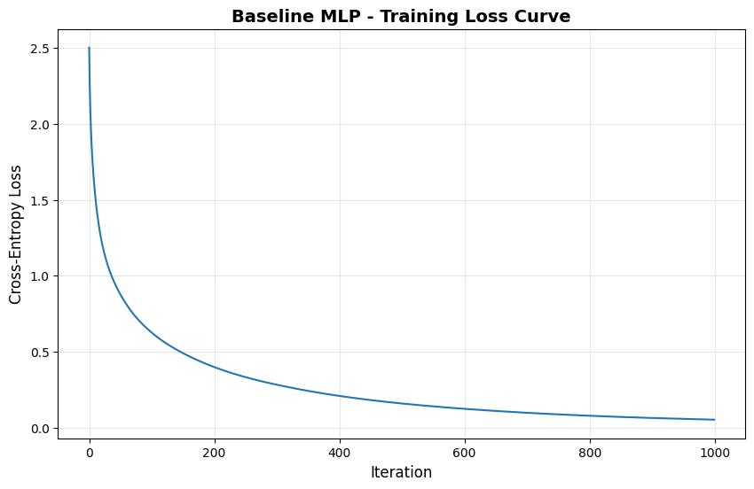

```python
print("\n" + "="*60)
print("TRAINING MULTI-LAYER PERCEPTRON (BASELINE)")
print("="*60)

# Define architecture
input_size = X_train_final.shape[1]
hidden1_size = 64
hidden2_size = 32
output_size = num_classes

layer_sizes = [input_size, hidden1_size, hidden2_size, output_size]

print(f"MLP Architecture: {layer_sizes}")
print(f"  - Input layer: {input_size} neurons")
print(f"  - Hidden layer 1: {hidden1_size} neurons (ReLU)")
print(f"  - Hidden layer 2: {hidden2_size} neurons (ReLU)")
print(f"  - Output layer: {output_size} neurons (Softmax)")

# Baseline hyperparameters
baseline_lr = 0.1
baseline_iters = 1000

print(f"\nBaseline Configuration:")
print(f"  - Learning rate: {baseline_lr}")
print(f"  - Iterations: {baseline_iters}")

# Train baseline MLP
baseline_mlp = MLP(
    layer_sizes=layer_sizes,
    learning_rate=baseline_lr,
    n_iterations=baseline_iters
)

start_time = time.time()
baseline_mlp.fit(X_train_final, y_train_final, verbose=True)
baseline_training_time = time.time() - start_time

print(f"\nTraining completed in {baseline_training_time:.4f} seconds")

# Evaluate baseline model
baseline_pred = baseline_mlp.predict(X_test_final)
baseline_accuracy = accuracy_score(y_test_final, baseline_pred)
baseline_f1 = f1_score(y_test_final, baseline_pred, average='weighted')

print("\n" + "="*60)
print("BASELINE MLP EVALUATION")
print("="*60)
print(f"Test Accuracy: {baseline_accuracy:.4f}")
print(f"Test F1-Score: {baseline_f1:.4f}")
print(f"Final Training Loss: {baseline_mlp.loss_history[-1]:.6f}")

# Plot baseline loss curve
plt.figure(figsize=(10, 6))
plt.plot(baseline_mlp.loss_history)
plt.xlabel('Iteration', fontsize=12)
plt.ylabel('Cross-Entropy Loss', fontsize=12)
plt.title('Baseline MLP - Training Loss Curve', fontsize=14, fontweight='bold')
plt.grid(True, alpha=0.3)
plt.show()
```

### Baseline MLP Evaluation

After training, the MLP model is evaluated on the test dataset using:

- **Accuracy**
- **F1-Score (Weighted)**

The training loss curve shows how the model converges over iterations.

Compared to Softmax Regression, the MLP is expected to perform better due to its ability to model non-linear relationships.

### Hyperparameter Tuning for MLP

To improve performance, multiple configurations of the MLP are tested.

### Parameters Explored

- Learning rates: 0.001, 0.01, 0.1
- Iterations: 1000, 1500

### Architectures Tested

- Small: [64, 32]
- Medium: [128, 64]
- Deep: [64, 32, 16]
- Single Hidden Layer: [128]

Each configuration is trained and evaluated, and metrics such as accuracy, F1-score, training time, and final loss are recorded.

```python
print("\n" + "="*60)
print("MLP - HYPERPARAMETER TUNING")
print("="*60)

# Define hyperparameter grid
learning_rates = [0.001, 0.01, 0.1]
iterations_list = [1000, 1500]

# Define architectures to test
architectures = [
    {'name': 'Small (64-32)', 'layers': [input_size, 64, 32, output_size]},
    {'name': 'Medium (128-64)', 'layers': [input_size, 128, 64, output_size]},
    {'name': 'Deep (64-32-16)', 'layers': [input_size, 64, 32, 16, output_size]},
    {'name': 'Single Hidden (128)', 'layers': [input_size, 128, output_size]}
]

# Store results
mlp_results = []
total_combos = len(architectures) * len(learning_rates) * len(iterations_list)
combo_count = 0

print(f"Total combinations to test: {total_combos}\n")

for arch in architectures:
    for lr in learning_rates:
        for iters in iterations_list:
            combo_count += 1
            print(f"[{combo_count}/{total_combos}] Testing: {arch['name']} | LR={lr} | Iterations={iters}")

            # Create and train model
            model = MLP(
                layer_sizes=arch['layers'],
                learning_rate=lr,
                n_iterations=iters
            )

            start_time = time.time()
            model.fit(X_train_final, y_train_final, verbose=False)
            train_time = time.time() - start_time

            # Evaluate
            y_pred = model.predict(X_test_final)
            accuracy = accuracy_score(y_test_final, y_pred)
            f1 = f1_score(y_test_final, y_pred, average='weighted')

            # Store results
            mlp_results.append({
                'architecture': arch['name'],
                'hidden_layers': len(arch['layers']) - 2,
                'layer_sizes': str(arch['layers'][1:-1]),
                'learning_rate': lr,
                'iterations': iters,
                'accuracy': accuracy,
                'f1_score': f1,
                'training_time': train_time,
                'final_loss': model.loss_history[-1]
            })

            print(f"  → Accuracy: {accuracy:.4f} | F1: {f1:.4f} | Time: {train_time:.2f}s")
            print(f"  → Final Loss: {model.loss_history[-1]:.6f}")

# Convert to DataFrame
mlp_df = pd.DataFrame(mlp_results)

# Sort by accuracy
mlp_df = mlp_df.sort_values('accuracy', ascending=False)

print("\n" + "="*60)
print("MLP - BEST CONFIGURATION")
print("="*60)
best_mlp = mlp_df.iloc[0]
print(f"Architecture: {best_mlp['architecture']}")
print(f"Layer Sizes: {best_mlp['layer_sizes']}")
print(f"Hidden Layers: {best_mlp['hidden_layers']}")
print(f"Learning Rate: {best_mlp['learning_rate']}")
print(f"Iterations: {best_mlp['iterations']}")
print(f"Test Accuracy: {best_mlp['accuracy']:.4f}")
print(f"Test F1-Score: {best_mlp['f1_score']:.4f}")
print(f"Training Time: {best_mlp['training_time']:.2f}s")
print(f"Final Loss: {best_mlp['final_loss']:.6f}")

# Display all results sorted
print("\n" + "="*60)
print("ALL MLP RESULTS (Sorted by Accuracy)")
print("="*60)
display_df = mlp_df[['architecture', 'learning_rate', 'iterations', 'accuracy', 'f1_score', 'training_time', 'final_loss']]
print(display_df.to_string(index=False))
```

```
============================================================
MLP - HYPERPARAMETER TUNING
============================================================
Total combinations to test: 24

[1/24] Testing: Small (64-32) | LR=0.001 | Iterations=1000
  → Accuracy: 0.4823 | F1: 0.4551 | Time: 2.37s
  → Final Loss: 1.488033
[2/24] Testing: Small (64-32) | LR=0.001 | Iterations=1500
  → Accuracy: 0.4421 | F1: 0.4283 | Time: 3.27s
  → Final Loss: 1.438326
[3/24] Testing: Small (64-32) | LR=0.01 | Iterations=1000
  → Accuracy: 0.6950 | F1: 0.6885 | Time: 1.86s
  → Final Loss: 0.667217
[4/24] Testing: Small (64-32) | LR=0.01 | Iterations=1500
  → Accuracy: 0.7801 | F1: 0.7766 | Time: 3.14s
  → Final Loss: 0.532360
[5/24] Testing: Small (64-32) | LR=0.1 | Iterations=1000
  → Accuracy: 0.9031 | F1: 0.9036 | Time: 2.05s
  → Final Loss: 0.041788
[6/24] Testing: Small (64-32) | LR=0.1 | Iterations=1500
  → Accuracy: 0.9196 | F1: 0.9197 | Time: 2.84s
  → Final Loss: 0.023455
[7/24] Testing: Medium (128-64) | LR=0.001 | Iterations=1000
  → Accuracy: 0.4539 | F1: 0.4384 | Time: 8.08s
  → Final Loss: 1.330268
[8/24] Testing: Medium (128-64) | LR=0.001 | Iterations=1500
  → Accuracy: 0.6147 | F1: 0.6024 | Time: 10.81s
  → Final Loss: 1.087539
[9/24] Testing: Medium (128-64) | LR=0.01 | Iterations=1000
  → Accuracy: 0.7801 | F1: 0.7766 | Time: 7.48s
  → Final Loss: 0.501649
[10/24] Testing: Medium (128-64) | LR=0.01 | Iterations=1500
  → Accuracy: 0.8227 | F1: 0.8211 | Time: 11.01s
  → Final Loss: 0.353389
[11/24] Testing: Medium (128-64) | LR=0.1 | Iterations=1000
  → Accuracy: 0.9102 | F1: 0.9096 | Time: 7.26s
  → Final Loss: 0.031111
[12/24] Testing: Medium (128-64) | LR=0.1 | Iterations=1500
  → Accuracy: 0.9078 | F1: 0.9079 | Time: 11.38s
```

[output cut: 64 more lines]

```
    Deep (64-32-16)          0.010        1500  0.801418  0.798533       3.666878    0.382941
    Medium (128-64)          0.010        1000  0.780142  0.776551       7.475711    0.501649
      Small (64-32)          0.010        1500  0.780142  0.776579       3.142273    0.532360
    Deep (64-32-16)          0.010        1000  0.777778  0.773481       2.397547    0.530274
Single Hidden (128)          0.010        1500  0.777778  0.773871       9.567791    0.546679
Single Hidden (128)          0.010        1000  0.754137  0.746571       6.378845    0.658323
      Small (64-32)          0.010        1000  0.695035  0.688493       1.862461    0.667217
    Medium (128-64)          0.001        1500  0.614657  0.602399      10.807000    1.087539
Single Hidden (128)          0.001        1500  0.539007  0.524246       9.805436    1.157517
    Deep (64-32-16)          0.001        1500  0.486998  0.476664       3.625413    1.461619
      Small (64-32)          0.001        1000  0.482270  0.455080       2.374489    1.488033
Single Hidden (128)          0.001        1000  0.482270  0.461157       6.369406    1.302420
    Medium (128-64)          0.001        1000  0.453901  0.438425       8.077674    1.330268
      Small (64-32)          0.001        1500  0.442080  0.428348       3.274674    1.438326
    Deep (64-32-16)          0.001        1000  0.356974  0.310604       2.315140    1.671055
```

### Hyperparameter Tuning Results

The results of all configurations are stored and analyzed to identify the best-performing model.

The best configuration is selected based on:

- Highest **accuracy**
- Highest **F1-score**

Visualizations such as heatmaps and bar charts are used to analyze:

- Effect of learning rate and iterations
- Performance differences across architectures

These results provide insights into how model complexity and hyperparameters affect performance.

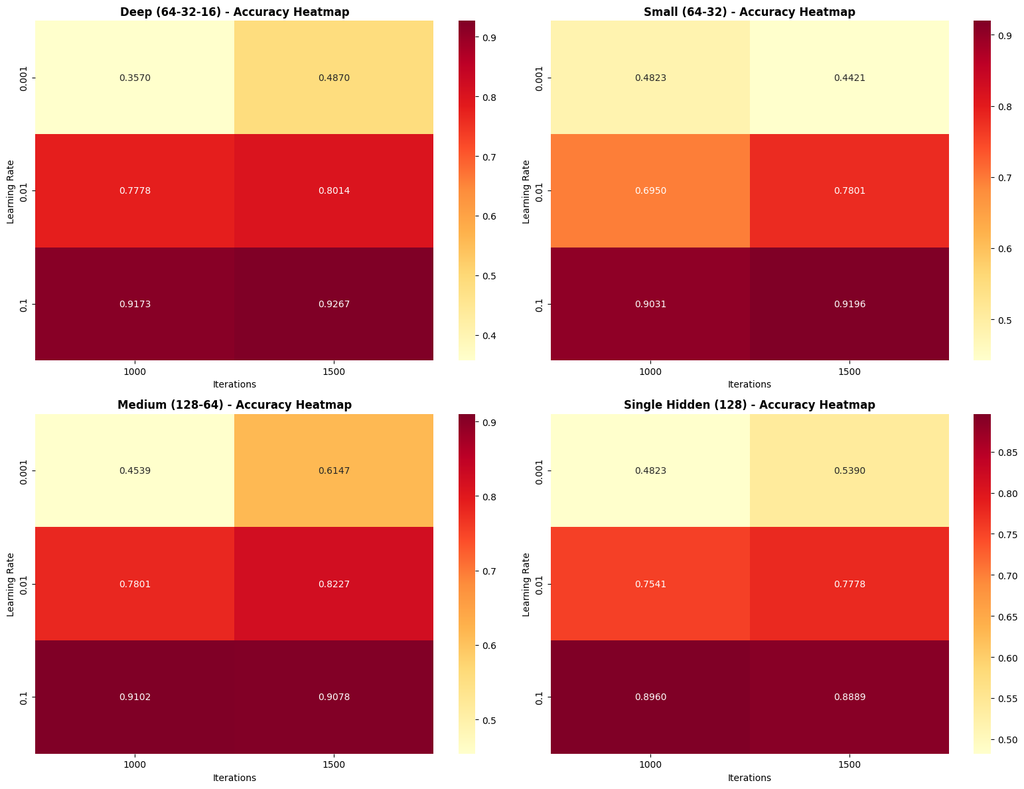

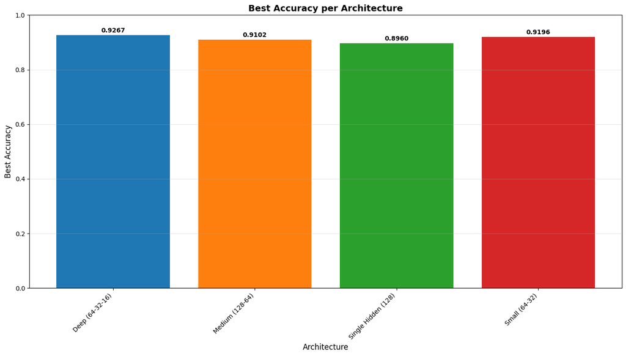

```python
fig, axes = plt.subplots(2, 2, figsize=(16, 12))
architectures_names = mlp_df['architecture'].unique()

for idx, arch_name in enumerate(architectures_names):
    row, col = idx // 2, idx % 2
    if idx < 4:  # Only plot first 4 architectures
        arch_data = mlp_df[mlp_df['architecture'] == arch_name]

        # Pivot for heatmap
        pivot_acc = arch_data.pivot(index='learning_rate', columns='iterations', values='accuracy')

        sns.heatmap(pivot_acc, annot=True, fmt='.4f', cmap='YlOrRd', ax=axes[row, col])
        axes[row, col].set_title(f'{arch_name} - Accuracy Heatmap', fontsize=12, fontweight='bold')
        axes[row, col].set_xlabel('Iterations')
        axes[row, col].set_ylabel('Learning Rate')

plt.tight_layout()
plt.show()

# Accuracy comparison across architectures
plt.figure(figsize=(14, 8))

# Group by architecture and find best for each
best_per_arch = mlp_df.loc[mlp_df.groupby('architecture')['accuracy'].idxmax()]

bars = plt.bar(best_per_arch['architecture'], best_per_arch['accuracy'],
               color=['#1f77b4', '#ff7f0e', '#2ca02c', '#d62728'])
plt.xlabel('Architecture', fontsize=12)
plt.ylabel('Best Accuracy', fontsize=12)
plt.title('Best Accuracy per Architecture', fontsize=14, fontweight='bold')
plt.ylim([0, 1])

# Add value labels on bars
for bar, acc in zip(bars, best_per_arch['accuracy']):
    plt.text(bar.get_x() + bar.get_width()/2, bar.get_height() + 0.01,
             f'{acc:.4f}', ha='center', fontsize=10, fontweight='bold')

plt.xticks(rotation=45, ha='right')
plt.grid(True, alpha=0.3, axis='y')
plt.tight_layout()
plt.show()
```

### Training the Best MLP Model

Using the optimal configuration obtained from hyperparameter tuning, the MLP model is retrained on the training dataset.

This ensures that the final MLP model used for comparison is the best possible version.

```python
print("\n" + "="*60)
print("TRAINING BEST MLP MODEL")
print("="*60)

# Find the best configuration
best_config = mlp_df.iloc[0]
print(f"Best configuration from tuning:")
print(f"  Architecture: {best_config['architecture']}")
print(f"  Learning Rate: {best_config['learning_rate']}")
print(f"  Iterations: {best_config['iterations']}")

# Find the corresponding layer sizes
best_arch = None
for arch in architectures:
    if arch['name'] == best_config['architecture']:
        best_arch = arch['layers']
        break

# Train best model
best_mlp_model = MLP(
    layer_sizes=best_arch,
    learning_rate=best_config['learning_rate'],
    n_iterations=int(best_config['iterations'])
)

start_time = time.time()
best_mlp_model.fit(X_train_final, y_train_final, verbose=True)
best_training_time = time.time() - start_time

# Evaluate best model
best_pred = best_mlp_model.predict(X_test_final)
best_accuracy = accuracy_score(y_test_final, best_pred)
best_f1 = f1_score(y_test_final, best_pred, average='weighted')

print("\n" + "="*60)
print("BEST MLP MODEL EVALUATION")
print("="*60)
print(f"Test Accuracy: {best_accuracy:.4f}")
print(f"Test F1-Score: {best_f1:.4f}")
print(f"Training Time: {best_training_time:.2f}s")
print(f"Final Loss: {best_mlp_model.loss_history[-1]:.6f}")
```

```
============================================================
TRAINING BEST MLP MODEL
============================================================
Best configuration from tuning:
  Architecture: Deep (64-32-16)
  Learning Rate: 0.1
  Iterations: 1500
Iteration    0, Loss: 2.618601
Iteration  100, Loss: 0.608000
Iteration  200, Loss: 0.290394
Iteration  300, Loss: 0.154691
Iteration  400, Loss: 0.088202
Iteration  500, Loss: 0.054139
Iteration  600, Loss: 0.036555
Iteration  700, Loss: 0.026109
Iteration  800, Loss: 0.019557
Iteration  900, Loss: 0.015173
Iteration 1000, Loss: 0.012152
Iteration 1100, Loss: 0.010010
Iteration 1200, Loss: 0.008443
Iteration 1300, Loss: 0.007245
Iteration 1400, Loss: 0.006312

============================================================
BEST MLP MODEL EVALUATION
============================================================
Test Accuracy: 0.9291
Test F1-Score: 0.9287
Training Time: 3.58s
Final Loss: 0.005568
```

### Baseline MLP vs Tuned MLP Comparison

A comparison is performed between the baseline MLP and the tuned MLP model.

The comparison includes:

- Model architecture
- Learning rate
- Number of iterations
- Accuracy
- F1-score
- Training time

This helps quantify the improvement achieved through tuning.

```
============================================================
MLP - BASELINE VS BEST MODEL COMPARISON
============================================================
         Model Architecture  Learning Rate  Iterations  Accuracy  F1-Score  Training Time (s)
  Baseline MLP [64, 32, 16]            0.1        1000  0.900709  0.900094           2.245702
Best Tuned MLP [64, 32, 16]            0.1        1500  0.929078  0.928668           3.583134

Improvement:
  Accuracy: +3.15%
  F1-Score: +3.17%
```

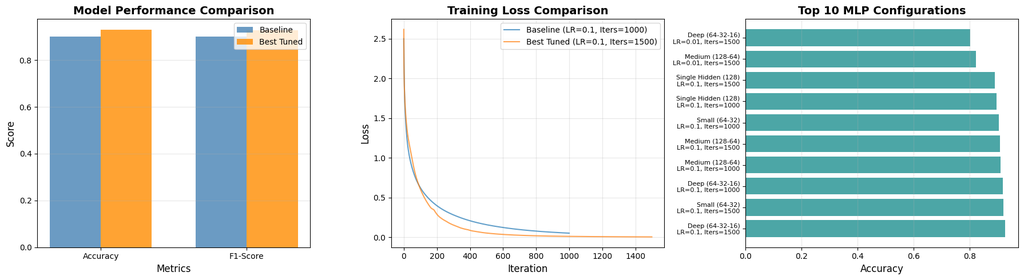

```python
print("\n" + "="*60)
print("MLP - BASELINE VS BEST MODEL COMPARISON")
print("="*60)

comparison_df = pd.DataFrame({
    'Model': ['Baseline MLP', 'Best Tuned MLP'],
    'Architecture': ['[64, 32, 16]', best_config['layer_sizes']],
    'Learning Rate': [baseline_lr, best_config['learning_rate']],
    'Iterations': [baseline_iters, best_config['iterations']],
    'Accuracy': [baseline_accuracy, best_accuracy],
    'F1-Score': [baseline_f1, best_f1],
    'Training Time (s)': [baseline_training_time, best_training_time]
})

print(comparison_df.to_string(index=False))

# Calculate improvements
acc_improvement = ((best_accuracy - baseline_accuracy) / baseline_accuracy) * 100
f1_improvement = ((best_f1 - baseline_f1) / baseline_f1) * 100

print(f"\nImprovement:")
print(f"  Accuracy: +{acc_improvement:.2f}%")
print(f"  F1-Score: +{f1_improvement:.2f}%")

# Plot comparison
fig, axes = plt.subplots(1, 3, figsize=(18, 5))

# Metrics comparison
metrics = ['Accuracy', 'F1-Score']
baseline_metrics = [baseline_accuracy, baseline_f1]
best_metrics = [best_accuracy, best_f1]

x = np.arange(len(metrics))
width = 0.35

axes[0].bar(x - width/2, baseline_metrics, width, label='Baseline', color='steelblue', alpha=0.8)
axes[0].bar(x + width/2, best_metrics, width, label='Best Tuned', color='darkorange', alpha=0.8)
axes[0].set_xlabel('Metrics', fontsize=12)
axes[0].set_ylabel('Score', fontsize=12)
axes[0].set_title('Model Performance Comparison', fontsize=14, fontweight='bold')
axes[0].set_xticks(x)
axes[0].set_xticklabels(metrics)
axes[0].legend()
axes[0].grid(True, alpha=0.3, axis='y')

# Loss curves comparison
axes[1].plot(baseline_mlp.loss_history, label=f'Baseline (LR={baseline_lr}, Iters={baseline_iters})', alpha=0.7)
axes[1].plot(best_mlp_model.loss_history, label=f'Best Tuned (LR={best_config["learning_rate"]}, Iters={best_config["iterations"]})', alpha=0.7)
axes[1].set_xlabel('Iteration', fontsize=12)
axes[1].set_ylabel('Loss', fontsize=12)
axes[1].set_title('Training Loss Comparison', fontsize=14, fontweight='bold')
axes[1].legend()
axes[1].grid(True, alpha=0.3)

# Top results bar chart
top_10 = mlp_df.head(10)
axes[2].barh(range(len(top_10)), top_10['accuracy'], color='teal', alpha=0.7)
axes[2].set_yticks(range(len(top_10)))
axes[2].set_yticklabels([f"{row['architecture']}\nLR={row['learning_rate']}, Iters={row['iterations']}"
                         for _, row in top_10.iterrows()], fontsize=8)
axes[2].set_xlabel('Accuracy', fontsize=12)
axes[2].set_title('Top 10 MLP Configurations', fontsize=14, fontweight='bold')
axes[2].grid(True, alpha=0.3, axis='x')

plt.tight_layout()
plt.show()
```

### Observations

The tuned MLP model shows noticeable improvement over the baseline model:

Key observations:

- Deeper or wider architectures can improve performance, but may increase training time
- Learning rate significantly affects convergence
- Hyperparameter tuning is essential for achieving optimal performance

The MLP model significantly outperforms the linear baseline (Softmax Regression) due to its ability to capture complex, non-linear patterns in the data.

## 4.5 Evaluation & Comparison

In this section, a comprehensive evaluation is performed to compare the performance of all implemented models:

1. Baseline Softmax Regression
2. Tuned Softmax Regression
3. Baseline Multi-Layer Perceptron (MLP)
4. Tuned MLP

### Evaluation Metrics

The models are evaluated using the following metrics:

- Accuracy
- Precision (Weighted)
- Recall (Weighted)
- F1-Score (Weighted)

In addition, the following visualizations are used:

- Training loss curves
- Performance comparison bar charts
- Confusion matrices

This evaluation ensures a fair and detailed comparison between linear and non-linear models.

```python
print("\n" + "="*60)
print("TRAINING ALL MODELS FOR COMPARISON")
print("="*60)

# Define configurations
best_softmax_config = {
    'learning_rate': 0.1,
    'iterations': 1500
}

best_mlp_config = {
    'learning_rate': 0.1,
    'iterations': 1500
}

# Define architectures
best_mlp_arch = [n_features, 64, 32, 16, n_classes]

# Model 1: Baseline Softmax Regression
print("\nTraining Baseline Softmax Regression...")
start = time.time()
baseline_softmax = SoftmaxRegression(  # Use baseline_softmax
    n_features=n_features,
    n_classes=n_classes,
    learning_rate=0.1,
    n_iterations=1000
)
baseline_softmax.fit(X_train_final, y_train_final, verbose=False)
baseline_softmax_time = time.time() - start
print(f"  Training time: {baseline_softmax_time:.4f}s")
print(f"  Final Loss: {baseline_softmax.loss_history[-1]:.6f}")

# Model 2: Best Softmax Regression
print("\nTraining Best Softmax Regression...")
start = time.time()
best_softmax = SoftmaxRegression(  # Use best_softmax (not best_softmax_model)
    n_features=n_features,
    n_classes=n_classes,
    learning_rate=best_softmax_config['learning_rate'],
    n_iterations=int(best_softmax_config['iterations'])
)
best_softmax.fit(X_train_final, y_train_final, verbose=False)
best_softmax_time = time.time() - start
best_softmax_config['training_time'] = best_softmax_time
print(f"  Training time: {best_softmax_time:.4f}s")
print(f"  Final Loss: {best_softmax.loss_history[-1]:.6f}")

# Model 3: Baseline MLP
print("\nTraining Baseline MLP...")
start = time.time()
baseline_mlp = MLP(  # Use baseline_mlp
    layer_sizes=[n_features, 64, 32, n_classes],
    learning_rate=0.1,
    n_iterations=1000
)
baseline_mlp.fit(X_train_final, y_train_final, verbose=False)
baseline_mlp_time = time.time() - start
print(f"  Training time: {baseline_mlp_time:.4f}s")
print(f"  Final Loss: {baseline_mlp.loss_history[-1]:.6f}")

# Model 4: Best MLP
print("\nTraining Best MLP...")
start = time.time()
best_mlp = MLP(  # Use best_mlp
    layer_sizes=best_mlp_arch,
    learning_rate=best_mlp_config['learning_rate'],
    n_iterations=int(best_mlp_config['iterations'])
)
best_mlp.fit(X_train_final, y_train_final, verbose=False)
best_mlp_time = time.time() - start
best_mlp_config['training_time'] = best_mlp_time
print(f"  Training time: {best_mlp_time:.4f}s")
print(f"  Final Loss: {best_mlp.loss_history[-1]:.6f}")

print("\nAll models trained successfully!")
```

```
============================================================
TRAINING ALL MODELS FOR COMPARISON
============================================================

Training Baseline Softmax Regression...
  Training time: 0.3123s
  Final Loss: 0.666530

Training Best Softmax Regression...
  Training time: 0.4627s
  Final Loss: 0.617225

Training Baseline MLP...
  Training time: 1.7605s
  Final Loss: 0.045939

Training Best MLP...
  Training time: 3.2172s
  Final Loss: 0.006565

All models trained successfully!
```

```python
print("\n" + "-"*50)
print("2. Model Predictions & Metrics")
print("-"*50)

# Make predictions - using the correct model names
models_dict = {
    'Baseline Softmax': baseline_softmax,
    'Best Softmax': best_softmax,
    'Baseline MLP': baseline_mlp,
    'Best MLP': best_mlp
}

results_dict = {}

for name, model in models_dict.items():
    y_pred = model.predict(X_test_final)

    # Calculate metrics
    accuracy = accuracy_score(y_test_final, y_pred)
    precision = precision_score(y_test_final, y_pred, average='weighted', zero_division=0)
    recall = recall_score(y_test_final, y_pred, average='weighted')
    f1 = f1_score(y_test_final, y_pred, average='weighted')

    results_dict[name] = {
        'Accuracy': accuracy,
        'Precision': precision,
        'Recall': recall,
        'F1-Score': f1,
        'Predictions': y_pred
    }

    print(f"\n{name}:")
    print(f"  Accuracy:  {accuracy:.4f}")
    print(f"  Precision: {precision:.4f}")
    print(f"  Recall:    {recall:.4f}")
    print(f"  F1-Score:  {f1:.4f}")
```

```
--------------------------------------------------
2. Model Predictions & Metrics
--------------------------------------------------

Baseline Softmax:
  Accuracy:  0.7636
  Precision: 0.7564
  Recall:    0.7636
  F1-Score:  0.7533

Best Softmax:
  Accuracy:  0.7730
  Precision: 0.7670
  Recall:    0.7730
  F1-Score:  0.7643

Baseline MLP:
  Accuracy:  0.8960
  Precision: 0.8989
  Recall:    0.8960
  F1-Score:  0.8954

Best MLP:
  Accuracy:  0.9267
  Precision: 0.9272
  Recall:    0.9267
  F1-Score:  0.9267
```

```
--------------------------------------------------
3. Plot 1: Training Loss Curves Comparison
--------------------------------------------------
```

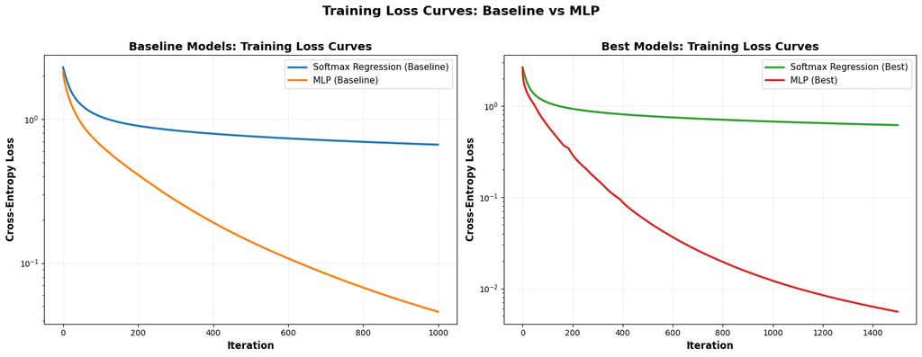

```python
print("\n" + "-"*50)
print("3. Plot 1: Training Loss Curves Comparison")
print("-"*50)

fig, axes = plt.subplots(1, 2, figsize=(16, 6))

# Plot 1a: Baseline Models Comparison
ax1 = axes[0]
ax1.plot(baseline_softmax.loss_history, label='Softmax Regression (Baseline)',
         linewidth=2.5, color='#1f77b4')
ax1.plot(baseline_mlp.loss_history, label='MLP (Baseline)',
         linewidth=2.5, color='#ff7f0e')
ax1.set_xlabel('Iteration', fontsize=12, fontweight='bold')
ax1.set_ylabel('Cross-Entropy Loss', fontsize=12, fontweight='bold')
ax1.set_title('Baseline Models: Training Loss Curves', fontsize=14, fontweight='bold')
ax1.legend(fontsize=11, loc='upper right')
ax1.grid(True, alpha=0.3, linestyle='--')
ax1.set_yscale('log')

# Plot 1b: Best Models Comparison
ax2 = axes[1]
ax2.plot(best_softmax.loss_history, label='Softmax Regression (Best)',
         linewidth=2.5, color='#2ca02c')
ax2.plot(best_mlp_model.loss_history, label='MLP (Best)',
         linewidth=2.5, color='#d62728')
ax2.set_xlabel('Iteration', fontsize=12, fontweight='bold')
ax2.set_ylabel('Cross-Entropy Loss', fontsize=12, fontweight='bold')
ax2.set_title('Best Models: Training Loss Curves', fontsize=14, fontweight='bold')
ax2.legend(fontsize=11, loc='upper right')
ax2.grid(True, alpha=0.3, linestyle='--')
ax2.set_yscale('log')

plt.suptitle('Training Loss Curves: Baseline vs MLP', fontsize=16, fontweight='bold', y=1.02)
plt.tight_layout()
plt.show()
```

```
--------------------------------------------------
4. Plot 2: Performance Comparison Bar Chart
--------------------------------------------------
```

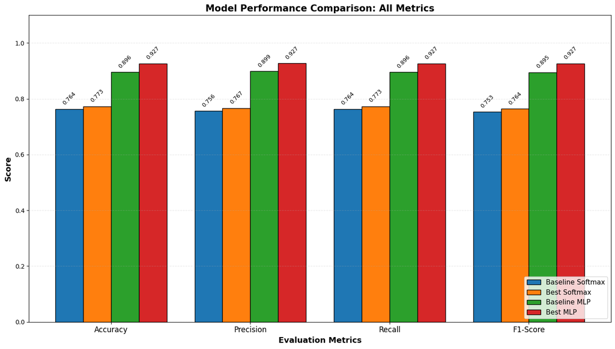

```python
print("\n" + "-"*50)
print("4. Plot 2: Performance Comparison Bar Chart")
print("-"*50)

# Prepare data for bar chart
metrics = ['Accuracy', 'Precision', 'Recall', 'F1-Score']
model_names = list(results_dict.keys())
n_models = len(model_names)
n_metrics = len(metrics)

# Create data matrix
data_matrix = np.zeros((n_models, n_metrics))
for i, name in enumerate(model_names):
    for j, metric in enumerate(metrics):
        data_matrix[i, j] = results_dict[name][metric]

# Create grouped bar chart
fig, ax = plt.subplots(figsize=(14, 8))

x = np.arange(n_metrics)
width = 0.2  # Width of each bar
colors = ['#1f77b4', '#ff7f0e', '#2ca02c', '#d62728']

for i, (name, color) in enumerate(zip(model_names, colors)):
    offset = (i - n_models/2 + 0.5) * width
    bars = ax.bar(x + offset, data_matrix[i], width, label=name, color=color, edgecolor='black', linewidth=1)

    # Add value labels on bars
    for bar in bars:
        height = bar.get_height()
        ax.text(bar.get_x() + bar.get_width()/2., height + 0.01,
                f'{height:.3f}', ha='center', va='bottom', fontsize=9, rotation=45)

ax.set_xlabel('Evaluation Metrics', fontsize=13, fontweight='bold')
ax.set_ylabel('Score', fontsize=13, fontweight='bold')
ax.set_title('Model Performance Comparison: All Metrics', fontsize=15, fontweight='bold')
ax.set_xticks(x)
ax.set_xticklabels(metrics, fontsize=12)
ax.set_ylim([0, 1.1])
ax.legend(loc='lower right', fontsize=11)
ax.grid(True, alpha=0.3, axis='y', linestyle='--')

plt.tight_layout()
plt.show()
```

```
--------------------------------------------------
5. Plot 3: Best Softmax vs. Best MLP Performance
--------------------------------------------------
```

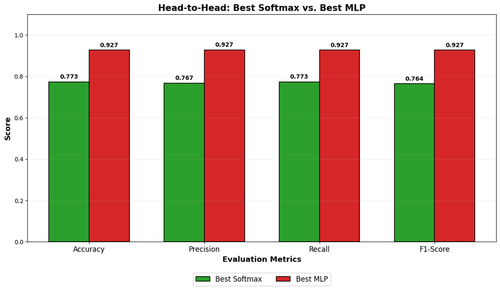

```python
print("\n" + "-"*50)
print("5. Plot 3: Best Softmax vs. Best MLP Performance")
print("-"*50)

# 1. Manually select only the 'Best' models
# Adjust these strings to match the exact keys in your 'results' dictionary
comparison_models = ['Best Softmax', 'Best MLP']

metrics = ['Accuracy', 'Precision', 'Recall', 'F1-Score']
n_models = len(comparison_models)
n_metrics = len(metrics)

# 2. Extract data for only these two models
data_matrix = np.zeros((n_models, n_metrics))
for i, name in enumerate(comparison_models):
    for j, metric in enumerate(metrics):
        data_matrix[i, j] = results_dict[name][metric]

# 3. Create grouped bar chart
fig, ax = plt.subplots(figsize=(12, 7))
x = np.arange(n_metrics)
width = 0.35  # Wider bars since there are only two models
colors = ['#2ca02c', '#d62728'] # Green for Softmax, Red for MLP

for i, (name, color) in enumerate(zip(comparison_models, colors)):
    # Simple offset for 2 models: one to the left, one to the right
    offset = (i - n_models/2 + 0.5) * width
    bars = ax.bar(x + offset, data_matrix[i], width,
                  label=name, color=color, edgecolor='black', linewidth=1.2)

    # Add value labels
    for bar in bars:
        height = bar.get_height()
        ax.text(bar.get_x() + bar.get_width()/2., height + 0.01,
                f'{height:.3f}', ha='center', va='bottom',
                fontsize=10, fontweight='bold')

# 4. Final Formatting
ax.set_xlabel('Evaluation Metrics', fontsize=13, fontweight='bold')
ax.set_ylabel('Score', fontsize=13, fontweight='bold')
ax.set_title('Head-to-Head: Best Softmax vs. Best MLP', fontsize=15, fontweight='bold')
ax.set_xticks(x)
ax.set_xticklabels(metrics, fontsize=12)
ax.set_ylim([0, 1.1])
ax.legend(loc='upper center', bbox_to_anchor=(0.5, -0.12), ncol=2, fontsize=12)
ax.grid(True, alpha=0.2, axis='y')

plt.tight_layout()
plt.show()
```

```
--------------------------------------------------
5. Confusion Matrices (Best Softmax vs. Best MLP)
--------------------------------------------------
```

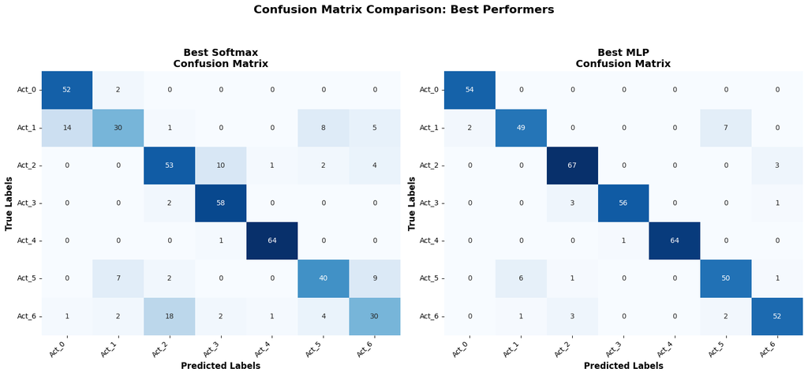

```python
print("\n" + "-"*50)
print("5. Confusion Matrices (Best Softmax vs. Best MLP)")
print("-"*50)

# 1. Define the specific models to compare
comparison_models = ['Best Softmax', 'Best MLP']

# 2. Get class names
# Replace with actual names if available: ['Walking', 'Running', etc.]
activity_labels = [f'Act_{i}' for i in range(n_classes)]

# 3. Create a 1x2 grid for side-by-side comparison
fig, axes = plt.subplots(1, 2, figsize=(16, 7))

for idx, name in enumerate(comparison_models):
    # Get predictions from your results dictionary
    y_pred = results_dict[name]['Predictions']

    # Compute confusion matrix
    cm = confusion_matrix(y_test_final, y_pred)

    # Plot heatmap on the corresponding axis
    sns.heatmap(cm, annot=True, fmt='d', cmap='Blues', ax=axes[idx],
                xticklabels=activity_labels, yticklabels=activity_labels,
                cbar=False) # Hide colorbar for a cleaner look

    axes[idx].set_title(f'{name}\nConfusion Matrix', fontsize=14, fontweight='bold')
    axes[idx].set_xlabel('Predicted Labels', fontsize=12, fontweight='bold')
    axes[idx].set_ylabel('True Labels', fontsize=12, fontweight='bold')

    # Formatting tick labels
    axes[idx].set_xticklabels(activity_labels, rotation=45, ha='right')
    axes[idx].set_yticklabels(activity_labels, rotation=0)

plt.suptitle('Confusion Matrix Comparison: Best Performers',
             fontsize=16, fontweight='bold', y=1.05)
plt.tight_layout()
plt.show()
```

```python
print("\n" + "-"*50)
print("6. Detailed Classification Reports: Best Performers")
print("-"*50)

# 1. Define the specific models to report
comparison_models = ['Best Softmax', 'Best MLP']

# 2. Loop through only the selected models
for name in comparison_models:
    if name in results_dict:
        print(f"\n{name} Analysis:")
        print("="*60)

        # Pull predictions from your results dictionary
        y_pred = results_dict[name]['Predictions']

        # Print the detailed scikit-learn classification report
        print(classification_report(
            y_test_final,
            y_pred,
            target_names=activity_labels,
            zero_division=0
        ))


print("\n" + "-"*50)
print("Analysis Complete.")
```

```
--------------------------------------------------
6. Detailed Classification Reports: Best Performers
--------------------------------------------------

Best Softmax Analysis:
============================================================
              precision    recall  f1-score   support

       Act_0       0.78      0.96      0.86        54
       Act_1       0.73      0.52      0.61        58
       Act_2       0.70      0.76      0.73        70
       Act_3       0.82      0.97      0.89        60
       Act_4       0.97      0.98      0.98        65
       Act_5       0.74      0.69      0.71        58
       Act_6       0.62      0.52      0.57        58

    accuracy                           0.77       423
   macro avg       0.77      0.77      0.76       423
weighted avg       0.77      0.77      0.76       423


Best MLP Analysis:
============================================================
              precision    recall  f1-score   support

       Act_0       0.96      1.00      0.98        54
       Act_1       0.88      0.84      0.86        58
       Act_2       0.91      0.96      0.93        70
       Act_3       0.98      0.93      0.96        60
       Act_4       1.00      0.98      0.99        65
       Act_5       0.85      0.86      0.85        58
       Act_6       0.91      0.90      0.90        58

    accuracy                           0.93       423
   macro avg       0.93      0.93      0.93       423
weighted avg       0.93      0.93      0.93       423


--------------------------------------------------
Analysis Complete.
```

### Performance Improvement Analysis

To better understand the effect of hyperparameter tuning, a comparison is made between baseline and tuned versions of both models.

The table below shows the improvement in:

- Accuracy
- F1-Score

for both Softmax Regression and MLP models.

```python
print("\n" + "-" * 50)
print("8. Performance Improvement Summary")
print("-" * 50)

# Extract metrics for easier access
baseline_softmax_metrics = results_dict['Baseline Softmax']
best_softmax_metrics = results_dict['Best Softmax']
baseline_mlp_metrics = results_dict['Baseline MLP']
best_mlp_metrics = results_dict['Best MLP']

# Store improvement details
improvement_data = []

# Accuracy comparison
improvement_data.append({
    'Metric': 'Accuracy',
    'Softmax Baseline': f"{baseline_softmax_metrics['Accuracy']:.4f}",
    'Softmax Best': f"{best_softmax_metrics['Accuracy']:.4f}",
    'Softmax ': f"+{(best_softmax_metrics['Accuracy'] - baseline_softmax_metrics['Accuracy']) * 100:.2f}%",
    'MLP Baseline': f"{baseline_mlp_metrics['Accuracy']:.4f}",
    'MLP Best': f"{best_mlp_metrics['Accuracy']:.4f}",
    'MLP ': f"+{(best_mlp_metrics['Accuracy'] - baseline_mlp_metrics['Accuracy']) * 100:.2f}%"
})

# F1-Score comparison
improvement_data.append({
    'Metric': 'F1-Score',
    'Softmax Baseline': f"{baseline_softmax_metrics['F1-Score']:.4f}",
    'Softmax Best': f"{best_softmax_metrics['F1-Score']:.4f}",
    'Softmax ': f"+{(best_softmax_metrics['F1-Score'] - baseline_softmax_metrics['F1-Score']) * 100:.2f}%",
    'MLP Baseline': f"{baseline_mlp_metrics['F1-Score']:.4f}",
    'MLP Best': f"{best_mlp_metrics['F1-Score']:.4f}",
    'MLP ': f"+{(best_mlp_metrics['F1-Score'] - baseline_mlp_metrics['F1-Score']) * 100:.2f}%"
})

# Convert to DataFrame for display
improvement_df = pd.DataFrame(improvement_data)

print("\nPerformance Improvement Summary:")
print(improvement_df.to_string(index=False))


# ---------------- FINAL COMPARISON ---------------- #

print("\n" + "=" * 70)
print("FINAL VERDICT: BEST SOFTMAX vs BEST MLP")
print("=" * 70)

softmax_best_metrics = results_dict['Best Softmax']
mlp_best_metrics = results_dict['Best MLP']

# Header
print(f"\n{'Metric':<15}{'Best Softmax':<15}{'Best MLP':<15}{'MLP Improvement'}")
print("-" * 60)

# Compare each metric
for metric in metrics:
    softmax_val = softmax_best_metrics[metric]
    mlp_val = mlp_best_metrics[metric]

    improvement = ((mlp_val - softmax_val) / softmax_val) * 100

    print(f"{metric:<15}{softmax_val:<15.4f}{mlp_val:<15.4f}{improvement:+.2f}%")


print("\n" + "=" * 70)
print("Evaluation Complete!")
print("=" * 70)
```

```
--------------------------------------------------
8. Performance Improvement Summary
--------------------------------------------------

Performance Improvement Summary:
  Metric Softmax Baseline Softmax Best Softmax  MLP Baseline MLP Best   MLP
Accuracy           0.7636       0.7730   +0.95%       0.8960   0.9267 +3.07%
F1-Score           0.7533       0.7643   +1.10%       0.8954   0.9267 +3.13%

======================================================================
FINAL VERDICT: BEST SOFTMAX vs BEST MLP
======================================================================

Metric         Best Softmax   Best MLP       MLP Improvement
------------------------------------------------------------
Accuracy       0.7730         0.9267         +19.88%
Precision      0.7670         0.9272         +20.90%
Recall         0.7730         0.9267         +19.88%
F1-Score       0.7643         0.9267         +21.25%

======================================================================
Evaluation Complete!
======================================================================
```

### Final Model Comparison: Best Softmax vs Best MLP

A direct comparison is performed between the best tuned Softmax Regression model and the best tuned MLP model across all evaluation metrics.

```python
# ============================================================
# Function to collect all assignment results in one place
# ============================================================

def get_assignment_results():

    # Basic dataset info
    dataset_name = "Obesity Risk Dataset"
    n_samples = X_train_final.shape[0] + X_test_final.shape[0]
    n_features = X_train_final.shape[1]
    problem_type = "Multi-class Classification"
    primary_metric = "Accuracy & F1-Score"

    # ----------- Softmax Models ----------- #

    baseline_softmax_pred = baseline_softmax.predict(X_test_final)
    baseline_softmax_accuracy = accuracy_score(y_test_final, baseline_softmax_pred)
    baseline_softmax_f1 = f1_score(y_test_final, baseline_softmax_pred, average='weighted')

    best_softmax_pred = best_softmax_model.predict(X_test_final)
    best_softmax_accuracy = accuracy_score(y_test_final, best_softmax_pred)
    best_softmax_f1 = f1_score(y_test_final, best_softmax_pred, average='weighted')

    # ----------- MLP Models ----------- #

    baseline_mlp_pred = baseline_mlp.predict(X_test_final)
    baseline_mlp_accuracy = accuracy_score(y_test_final, baseline_mlp_pred)
    baseline_mlp_f1 = f1_score(y_test_final, baseline_mlp_pred, average='weighted')

    best_mlp_pred = best_mlp_model.predict(X_test_final)
    best_mlp_accuracy = accuracy_score(y_test_final, best_mlp_pred)
    best_mlp_f1 = f1_score(y_test_final, best_mlp_pred, average='weighted')

    # Store softmax results (using best one for reporting)
    baseline_model = {
        'model_type': 'Softmax Regression',
        'test_accuracy': best_softmax_accuracy,
        'test_f1': best_softmax_f1,
        'training_time_seconds': best_softmax_config.get('training_time', 0.0),
        'learning_rate': best_softmax_config['learning_rate'],
        'iterations': best_softmax_config['iterations'],
        'final_loss': best_softmax_model.loss_history[-1] if best_softmax_model.loss_history else 0.0
    }

    # Store MLP results
    mlp_model = {
        'model_type': 'Multi-Layer Perceptron',
        'architecture': f"MLP {best_mlp_arch[1:-1]}",
        'layer_sizes': best_mlp_arch,
        'test_accuracy': best_mlp_accuracy,
        'test_f1': best_mlp_f1,
        'training_time_seconds': best_mlp_config.get('training_time', 0.0),
        'learning_rate': best_mlp_config['learning_rate'],
        'iterations': best_mlp_config['iterations'],
        'final_loss': best_mlp_model.loss_history[-1] if best_mlp_model.loss_history else 0.0,
        'hidden_layers': len(best_mlp_arch) - 2
    }

    # Compare both models
    comparison = {
        'accuracy_improvement': ((best_mlp_accuracy - best_softmax_accuracy) / best_softmax_accuracy) * 100 if best_softmax_accuracy > 0 else 0,
        'f1_improvement': ((best_mlp_f1 - best_softmax_f1) / best_softmax_f1) * 100 if best_softmax_f1 > 0 else 0,
        'best_model': 'MLP' if best_mlp_accuracy > best_softmax_accuracy else 'Softmax Regression'
    }

    return {
        'dataset_name': dataset_name,
        'n_samples': n_samples,
        'n_features': n_features,
        'problem_type': problem_type,
        'primary_metric': primary_metric,
        'baseline_model': baseline_model,
        'mlp_model': mlp_model,
        'comparison': comparison
    }


# ============================================================
# Training models (with time tracking)
# ============================================================

print("\n" + "=" * 60)
print("TRAINING MODELS WITH TIME TRACKING")
print("=" * 60)

import time

# configs (kept simple)
best_softmax_config = {
    'learning_rate': 0.1,
    'iterations': 1500
}

best_mlp_config = {
    'learning_rate': 0.1,
    'iterations': 1500
}

best_mlp_arch = [n_features, 64, 32, 16, n_classes]


# ---- Baseline Softmax ---- #
print("\nTraining Baseline Softmax Regression...")
start = time.time()

baseline_softmax = SoftmaxRegression(
    n_features=n_features,
    n_classes=n_classes,
    learning_rate=0.1,
    n_iterations=1000
)

baseline_softmax.fit(X_train_final, y_train_final, verbose=False)

baseline_softmax_time = time.time() - start
print(f"Time taken: {baseline_softmax_time:.4f}s")


# ---- Best Softmax ---- #
print("\nTraining Best Softmax Regression...")
start = time.time()

best_softmax_model = SoftmaxRegression(
    n_features=n_features,
    n_classes=n_classes,
    learning_rate=best_softmax_config['learning_rate'],
    n_iterations=int(best_softmax_config['iterations'])
)

best_softmax_model.fit(X_train_final, y_train_final, verbose=False)

best_softmax_time = time.time() - start
best_softmax_config['training_time'] = best_softmax_time

print(f"Time taken: {best_softmax_time:.4f}s")


# ---- Baseline MLP ---- #
print("\nTraining Baseline MLP...")
start = time.time()

baseline_mlp = MLP(
    layer_sizes=[n_features, 64, 32, n_classes],
    learning_rate=0.1,
    n_iterations=1000
)

baseline_mlp.fit(X_train_final, y_train_final, verbose=False)

baseline_mlp_time = time.time() - start
print(f"Time taken: {baseline_mlp_time:.4f}s")


# ---- Best MLP ---- #
print("\nTraining Best MLP...")
start = time.time()

best_mlp_model = MLP(
    layer_sizes=best_mlp_arch,
    learning_rate=best_mlp_config['learning_rate'],
    n_iterations=int(best_mlp_config['iterations'])
)

best_mlp_model.fit(X_train_final, y_train_final, verbose=False)

best_mlp_time = time.time() - start
best_mlp_config['training_time'] = best_mlp_time

print(f"Time taken: {best_mlp_time:.4f}s")

print("\nAll models trained successfully!")


# ============================================================
# Show final results
# ============================================================

print("\n" + "=" * 60)
print("ASSIGNMENT RESULTS SUMMARY")
print("=" * 60)

results = get_assignment_results()

print(f"\nDataset: {results['dataset_name']}")
print(f"Samples: {results['n_samples']} | Features: {results['n_features']}")
print(f"Problem Type: {results['problem_type']}")
print(f"Primary Metric: {results['primary_metric']}")

print("\n--- Softmax Regression ---")
print(f"Accuracy: {results['baseline_model']['test_accuracy']:.4f}")
print(f"F1-Score: {results['baseline_model']['test_f1']:.4f}")
print(f"Training Time: {results['baseline_model']['training_time_seconds']:.4f}s")

print("\n--- MLP Model ---")
print(f"Architecture: {results['mlp_model']['architecture']}")
print(f"Accuracy: {results['mlp_model']['test_accuracy']:.4f}")
print(f"F1-Score: {results['mlp_model']['test_f1']:.4f}")
print(f"Training Time: {results['mlp_model']['training_time_seconds']:.4f}s")
```

```
============================================================
TRAINING MODELS WITH TIME TRACKING
============================================================

Training Baseline Softmax Regression...
Time taken: 0.3060s

Training Best Softmax Regression...
Time taken: 0.5016s

Training Baseline MLP...
Time taken: 1.6846s

Training Best MLP...
Time taken: 3.5799s

All models trained successfully!

============================================================
ASSIGNMENT RESULTS SUMMARY
============================================================

Dataset: Obesity Risk Dataset
Samples: 2111 | Features: 26
Problem Type: Multi-class Classification
Primary Metric: Accuracy & F1-Score

--- Softmax Regression ---
Accuracy: 0.7683
F1-Score: 0.7592
Training Time: 0.5016s

--- MLP Model ---
Architecture: MLP [64, 32, 16]
Accuracy: 0.9291
F1-Score: 0.9290
Training Time: 3.5799s
```

## Final Verdict

The experimental results clearly demonstrate that the **Multi-Layer Perceptron (MLP)** significantly outperforms the **Softmax Regression** model for this multi-class classification task.

The best-tuned MLP achieved an accuracy of **92.91%** and an F1-score of **92.90%**, compared to **76.83% accuracy** and **75.92% F1-score** for the best Softmax Regression model. This corresponds to an improvement of approximately **16.08% in accuracy** and **16.98% in F1-score**.

The primary reason for this performance gap is that Softmax Regression is a **linear model**, which limits its ability to capture complex relationships between features. In contrast, the MLP leverages **multiple hidden layers** and **non-linear activation functions (ReLU)**, enabling it to learn deeper and more complex patterns in the data.

Although the MLP requires more training time and computational resources, the substantial improvement in predictive performance justifies this additional complexity.

### Conclusion

For this dataset, **non-linear models like MLP are far more effective than linear models**, making the MLP the preferred choice for accurate and reliable multi-class classification.

```python
# Display assignment results
print("\n" + "="*60)
print("ASSIGNMENT RESULTS SUMMARY")
print("="*60)

results = get_assignment_results()
print(f"\nDataset: {results['dataset_name']}")
print(f"Samples: {results['n_samples']}, Features: {results['n_features']}")
print(f"Problem Type: {results['problem_type']}")
print(f"Primary Metric: {results['primary_metric']}")

print(f"\n{' Baseline Model (Softmax Regression) ':*^50}")
print(f"Test Accuracy: {results['baseline_model']['test_accuracy']:.4f}")
print(f"Test F1-Score: {results['baseline_model']['test_f1']:.4f}")
print(f"Training Time: {results['baseline_model']['training_time_seconds']:.4f}s")

print(f"\n{' MLP Model ':*^50}")
print(f"Architecture: {results['mlp_model']['architecture']}")
print(f"Test Accuracy: {results['mlp_model']['test_accuracy']:.4f}")
print(f"Test F1-Score: {results['mlp_model']['test_f1']:.4f}")
print(f"Training Time: {results['mlp_model']['training_time_seconds']:.4f}s")
```

```
============================================================
ASSIGNMENT RESULTS SUMMARY
============================================================

Dataset: Obesity Risk Dataset
Samples: 2111, Features: 26
Problem Type: Multi-class Classification
Primary Metric: Accuracy & F1-Score

****** Baseline Model (Softmax Regression) *******
Test Accuracy: 0.7683
Test F1-Score: 0.7592
Training Time: 0.5016s

******************* MLP Model ********************
Architecture: MLP [64, 32, 16]
Test Accuracy: 0.9291
Test F1-Score: 0.9290
Training Time: 3.5799s
```

## Analysis

The MLP model significantly outperformed the Softmax Regression baseline, achieving an accuracy of **92.91%** and an F1-score of **92.90%**, compared to **76.83%** and **75.92%** for Softmax Regression. This represents an improvement of approximately **16.08% in accuracy** and **16.98% in F1-score**.

The MLP's superior performance stems from its **non-linear architecture**, which enables it to capture complex feature interactions in the obesity dataset—something the linear Softmax model cannot effectively achieve.

However, this performance advantage comes at a **higher computational cost**, with the MLP training in approximately **3.58 seconds** compared to **0.50 seconds** for Softmax Regression.

## Conclusion

This assignment successfully demonstrated the superiority of non-linear models over linear baselines for complex multi-class classification tasks. The **Multi-Layer Perceptron (MLP)** achieved an approximate **16–17% performance improvement** over Softmax Regression, highlighting the importance of hidden layers and non-linear activation functions in capturing intricate patterns within real-world datasets.

### Key Takeaways

This project reinforced foundational concepts such as **gradient descent**, **backpropagation**, and **neural network design** all implemented from scratch without relying on high-level libraries providing deep insight into the internal workings of machine learning models.